# R : Implementing Gradient Descent Algorithm in Estimating Regression Coefficients

John Pauline Pineda

2023-01-13

# **1. Table of Contents**

This document implements the gradient descent algorithm to estimate regression coefficients using various helpful packages in **R**.

## 1.1 Sample Data

The **Solubility** dataset from the **AppliedPredictiveModeling** package was used for this illustrated example. Other original predictors were removed from the dataset leaving only a subset of numeric predictors used during the analysis.  
Preliminary dataset assessment:  
**[A]** 951 rows (observations)  
**[A.1]** Train Set = 951 observations  
**[B]** 6 columns (variables)  
**[B.1]** 1/6 response = Log_Solubility variable (numeric)  
**[B.2]** 5/6 predictors = All remaining variables (0/5 factor + 5/5 numeric)

```r
##################################
# Loading R libraries
##################################
library(AppliedPredictiveModeling)
library(caret)
library(rpart)
library(lattice)
library(dplyr)
library(tidyr)
library(moments)
library(skimr)
library(RANN)
library(pls)
library(corrplot)
library(tidyverse)
library(lares)
library(DMwR)
library(gridExtra)
library(rattle)
library(rpart.plot)
library(RColorBrewer)
library(stats)

##################################
# Loading source and
# formulating the train set
##################################
data(solubility)
Solubility_Train <- as.data.frame(cbind(solTrainY,solTrainX))

##################################
# Selecting only a subset of
# numeric predictors for the train set
##################################
Solubility_Train <- Solubility_Train[,c("solTrainY",
                                        "MolWeight",
                                        "NumCarbon",
                                        "NumChlorine",
                                        "NumHalogen",
                                        "NumMultBonds")]

##################################
# Performing a general exploration of the train set
##################################
dim(Solubility_Train)
```

```
## [1] 951   6
```

```r
str(Solubility_Train)
```

```
## 'data.frame':    951 obs. of  6 variables:
##  $ solTrainY   : num  -3.97 -3.98 -3.99 -4 -4.06 -4.08 -4.08 -4.1 -4.1 -4.11 ...
##  $ MolWeight   : num  208 366 206 136 230 ...
##  $ NumCarbon   : int  14 21 13 10 9 10 17 12 22 14 ...
##  $ NumChlorine : int  0 0 0 0 1 2 2 0 0 0 ...
##  $ NumHalogen  : int  0 0 0 0 1 2 2 0 1 0 ...
##  $ NumMultBonds: int  16 13 7 2 6 2 18 1 4 7 ...
```

```r
summary(Solubility_Train)
```

```
##    solTrainY         MolWeight        NumCarbon       NumChlorine
##  Min.   :-11.620   Min.   : 46.09   Min.   : 1.000   Min.   : 0.0000
##  1st Qu.: -3.955   1st Qu.:122.61   1st Qu.: 6.000   1st Qu.: 0.0000
##  Median : -2.510   Median :179.23   Median : 9.000   Median : 0.0000
##  Mean   : -2.719   Mean   :201.65   Mean   : 9.893   Mean   : 0.5563
##  3rd Qu.: -1.360   3rd Qu.:264.34   3rd Qu.:12.000   3rd Qu.: 0.0000
##  Max.   :  1.580   Max.   :665.81   Max.   :33.000   Max.   :10.0000
##    NumHalogen       NumMultBonds
##  Min.   : 0.0000   Min.   : 0.000
##  1st Qu.: 0.0000   1st Qu.: 1.000
##  Median : 0.0000   Median : 6.000
##  Mean   : 0.6982   Mean   : 6.148
##  3rd Qu.: 1.0000   3rd Qu.:10.000
##  Max.   :10.0000   Max.   :25.000
```

```r
##################################
# Formulating a data type assessment summary
##################################
PDA <- Solubility_Train
(PDA.Summary <- data.frame(
  Column.Index=c(1:length(names(PDA))),
  Column.Name= names(PDA),
  Column.Type=sapply(PDA, function(x) class(x)),
  row.names=NULL)
)
```

```
##   Column.Index  Column.Name Column.Type
## 1            1    solTrainY     numeric
## 2            2    MolWeight     numeric
## 3            3    NumCarbon     integer
## 4            4  NumChlorine     integer
## 5            5   NumHalogen     integer
## 6            6 NumMultBonds     integer
```

## 1.2 Data Quality Assessment

Data quality assessment:  
**[A]** No missing observations noted for any variable.  
**[B]** Low variance observed for 2 variables with First.Second.Mode.Ratio>5.  
**[B.1]** NumChlorine variable (numeric)  
**[B.2]** NumHalogen variable (numeric)  
**[C]** No low variance observed for any variable with Unique.Count.Ratio<0.01.  
**[D]** High skewness observed for 1 variable with Skewness>3 or Skewness<(-3).  
**[D.1]** NumChlorine variable (numeric)

```r
##################################
# Loading dataset
##################################
DQA <- Solubility_Train

##################################
# Formulating an overall data quality assessment summary
##################################
(DQA.Summary <- data.frame(
  Column.Index=c(1:length(names(DQA))),
  Column.Name= names(DQA),
  Column.Type=sapply(DQA, function(x) class(x)),
  Row.Count=sapply(DQA, function(x) nrow(DQA)),
  NA.Count=sapply(DQA,function(x)sum(is.na(x))),
  Fill.Rate=sapply(DQA,function(x)format(round((sum(!is.na(x))/nrow(DQA)),3),nsmall=3)),
  row.names=NULL)
)
```

```
##   Column.Index  Column.Name Column.Type Row.Count NA.Count Fill.Rate
## 1            1    solTrainY     numeric       951        0     1.000
## 2            2    MolWeight     numeric       951        0     1.000
## 3            3    NumCarbon     integer       951        0     1.000
## 4            4  NumChlorine     integer       951        0     1.000
## 5            5   NumHalogen     integer       951        0     1.000
## 6            6 NumMultBonds     integer       951        0     1.000
```

```r
##################################
# Listing all predictors
##################################
DQA.Predictors <- DQA[,!names(DQA) %in% c("solTrainY")]

##################################
# Listing all numeric predictors
##################################
DQA.Predictors.Numeric <- DQA.Predictors[,sapply(DQA.Predictors, is.numeric)]

if (length(names(DQA.Predictors.Numeric))>0) {
    print(paste0("There are ",
               (length(names(DQA.Predictors.Numeric))),
               " numeric predictor variable(s)."))
} else {
  print("There are no numeric predictor variables.")
}
```

```
## [1] "There are 5 numeric predictor variable(s)."
```

```r
##################################
# Listing all factor predictors
##################################
DQA.Predictors.Factor <- DQA.Predictors[,sapply(DQA.Predictors, is.factor)]

if (length(names(DQA.Predictors.Factor))>0) {
    print(paste0("There are ",
               (length(names(DQA.Predictors.Factor))),
               " factor predictor variable(s)."))
} else {
  print("There are no factor predictor variables.")
}
```

```
## [1] "There are no factor predictor variables."
```

```r
##################################
# Formulating a data quality assessment summary for factor predictors
##################################
if (length(names(DQA.Predictors.Factor))>0) {

  ##################################
  # Formulating a function to determine the first mode
  ##################################
  FirstModes <- function(x) {
    ux <- unique(na.omit(x))
    tab <- tabulate(match(x, ux))
    ux[tab == max(tab)]
  }

  ##################################
  # Formulating a function to determine the second mode
  ##################################
  SecondModes <- function(x) {
    ux <- unique(na.omit(x))
    tab <- tabulate(match(x, ux))
    fm = ux[tab == max(tab)]
    sm = x[!(x %in% fm)]
    usm <- unique(sm)
    tabsm <- tabulate(match(sm, usm))
    ifelse(is.na(usm[tabsm == max(tabsm)])==TRUE,
           return("x"),
           return(usm[tabsm == max(tabsm)]))
  }

  (DQA.Predictors.Factor.Summary <- data.frame(
  Column.Name= names(DQA.Predictors.Factor),
  Column.Type=sapply(DQA.Predictors.Factor, function(x) class(x)),
  Unique.Count=sapply(DQA.Predictors.Factor, function(x) length(unique(x))),
  First.Mode.Value=sapply(DQA.Predictors.Factor, function(x) as.character(FirstModes(x)[1])),
  Second.Mode.Value=sapply(DQA.Predictors.Factor, function(x) as.character(SecondModes(x)[1])),
  First.Mode.Count=sapply(DQA.Predictors.Factor, function(x) sum(na.omit(x) == FirstModes(x)[1])),
  Second.Mode.Count=sapply(DQA.Predictors.Factor, function(x) sum(na.omit(x) == SecondModes(x)[1])),
  Unique.Count.Ratio=sapply(DQA.Predictors.Factor, function(x) format(round((length(unique(x))/nrow(DQA.Predictors.Factor)),3), nsmall=3)),
  First.Second.Mode.Ratio=sapply(DQA.Predictors.Factor, function(x) format(round((sum(na.omit(x) == FirstModes(x)[1])/sum(na.omit(x) == SecondModes(x)[1])),3), nsmall=3)),
  row.names=NULL)
  )

}

##################################
# Formulating a data quality assessment summary for numeric predictors
##################################
if (length(names(DQA.Predictors.Numeric))>0) {

  ##################################
  # Formulating a function to determine the first mode
  ##################################
  FirstModes <- function(x) {
    ux <- unique(na.omit(x))
    tab <- tabulate(match(x, ux))
    ux[tab == max(tab)]
  }

  ##################################
  # Formulating a function to determine the second mode
  ##################################
  SecondModes <- function(x) {
    ux <- unique(na.omit(x))
    tab <- tabulate(match(x, ux))
    fm = ux[tab == max(tab)]
    sm = na.omit(x)[!(na.omit(x) %in% fm)]
    usm <- unique(sm)
    tabsm <- tabulate(match(sm, usm))
    ifelse(is.na(usm[tabsm == max(tabsm)])==TRUE,
           return(0.00001),
           return(usm[tabsm == max(tabsm)]))
  }

  (DQA.Predictors.Numeric.Summary <- data.frame(
  Column.Name= names(DQA.Predictors.Numeric),
  Column.Type=sapply(DQA.Predictors.Numeric, function(x) class(x)),
  Unique.Count=sapply(DQA.Predictors.Numeric, function(x) length(unique(x))),
  Unique.Count.Ratio=sapply(DQA.Predictors.Numeric, function(x) format(round((length(unique(x))/nrow(DQA.Predictors.Numeric)),3), nsmall=3)),
  First.Mode.Value=sapply(DQA.Predictors.Numeric, function(x) format(round((FirstModes(x)[1]),3),nsmall=3)),
  Second.Mode.Value=sapply(DQA.Predictors.Numeric, function(x) format(round((SecondModes(x)[1]),3),nsmall=3)),
  First.Mode.Count=sapply(DQA.Predictors.Numeric, function(x) sum(na.omit(x) == FirstModes(x)[1])),
  Second.Mode.Count=sapply(DQA.Predictors.Numeric, function(x) sum(na.omit(x) == SecondModes(x)[1])),
  First.Second.Mode.Ratio=sapply(DQA.Predictors.Numeric, function(x) format(round((sum(na.omit(x) == FirstModes(x)[1])/sum(na.omit(x) == SecondModes(x)[1])),3), nsmall=3)),
  Minimum=sapply(DQA.Predictors.Numeric, function(x) format(round(min(x,na.rm = TRUE),3), nsmall=3)),
  Mean=sapply(DQA.Predictors.Numeric, function(x) format(round(mean(x,na.rm = TRUE),3), nsmall=3)),
  Median=sapply(DQA.Predictors.Numeric, function(x) format(round(median(x,na.rm = TRUE),3), nsmall=3)),
  Maximum=sapply(DQA.Predictors.Numeric, function(x) format(round(max(x,na.rm = TRUE),3), nsmall=3)),
  Skewness=sapply(DQA.Predictors.Numeric, function(x) format(round(skewness(x,na.rm = TRUE),3), nsmall=3)),
  Kurtosis=sapply(DQA.Predictors.Numeric, function(x) format(round(kurtosis(x,na.rm = TRUE),3), nsmall=3)),
  Percentile25th=sapply(DQA.Predictors.Numeric, function(x) format(round(quantile(x,probs=0.25,na.rm = TRUE),3), nsmall=3)),
  Percentile75th=sapply(DQA.Predictors.Numeric, function(x) format(round(quantile(x,probs=0.75,na.rm = TRUE),3), nsmall=3)),
  row.names=NULL)
  )

}
```

```
##    Column.Name Column.Type Unique.Count Unique.Count.Ratio First.Mode.Value
## 1    MolWeight     numeric          646              0.679          102.200
## 2    NumCarbon     integer           28              0.029            6.000
## 3  NumChlorine     integer           11              0.012            0.000
## 4   NumHalogen     integer           11              0.012            0.000
## 5 NumMultBonds     integer           25              0.026            0.000
##   Second.Mode.Value First.Mode.Count Second.Mode.Count First.Second.Mode.Ratio
## 1           116.230               16                14                   1.143
## 2             7.000              105                97                   1.082
## 3             1.000              750                81                   9.259
## 4             1.000              685               107                   6.402
## 5             7.000              158               122                   1.295
##   Minimum    Mean  Median Maximum Skewness Kurtosis Percentile25th
## 1  46.090 201.654 179.230 665.810    0.988    3.945        122.605
## 2   1.000   9.893   9.000  33.000    0.927    3.616          6.000
## 3   0.000   0.556   0.000  10.000    3.178   13.780          0.000
## 4   0.000   0.698   0.000  10.000    2.691   10.808          0.000
## 5   0.000   6.148   6.000  25.000    0.670    3.053          1.000
##   Percentile75th
## 1        264.340
## 2         12.000
## 3          0.000
## 4          1.000
## 5         10.000
```

```r
##################################
# Identifying potential data quality issues
##################################

##################################
# Checking for missing observations
##################################
if ((nrow(DQA.Summary[DQA.Summary$NA.Count>0,]))>0){
  print(paste0("Missing observations noted for ",
               (nrow(DQA.Summary[DQA.Summary$NA.Count>0,])),
               " variable(s) with NA.Count>0 and Fill.Rate<1.0."))
  DQA.Summary[DQA.Summary$NA.Count>0,]
} else {
  print("No missing observations noted.")
}
```

```
## [1] "No missing observations noted."
```

```r
##################################
# Checking for zero or near-zero variance predictors
##################################
if (length(names(DQA.Predictors.Factor))==0) {
  print("No factor predictors noted.")
} else if (nrow(DQA.Predictors.Factor.Summary[as.numeric(as.character(DQA.Predictors.Factor.Summary$First.Second.Mode.Ratio))>5,])>0){
  print(paste0("Low variance observed for ",
               (nrow(DQA.Predictors.Factor.Summary[as.numeric(as.character(DQA.Predictors.Factor.Summary$First.Second.Mode.Ratio))>5,])),
               " factor variable(s) with First.Second.Mode.Ratio>5."))
  DQA.Predictors.Factor.Summary[as.numeric(as.character(DQA.Predictors.Factor.Summary$First.Second.Mode.Ratio))>5,]
} else {
  print("No low variance factor predictors due to high first-second mode ratio noted.")
}
```

```
## [1] "No factor predictors noted."
```

```r
if (length(names(DQA.Predictors.Numeric))==0) {
  print("No numeric predictors noted.")
} else if (nrow(DQA.Predictors.Numeric.Summary[as.numeric(as.character(DQA.Predictors.Numeric.Summary$First.Second.Mode.Ratio))>5,])>0){
  print(paste0("Low variance observed for ",
               (nrow(DQA.Predictors.Numeric.Summary[as.numeric(as.character(DQA.Predictors.Numeric.Summary$First.Second.Mode.Ratio))>5,])),
               " numeric variable(s) with First.Second.Mode.Ratio>5."))
  DQA.Predictors.Numeric.Summary[as.numeric(as.character(DQA.Predictors.Numeric.Summary$First.Second.Mode.Ratio))>5,]
} else {
  print("No low variance numeric predictors due to high first-second mode ratio noted.")
}
```

```
## [1] "Low variance observed for 2 numeric variable(s) with First.Second.Mode.Ratio>5."
```

```
##   Column.Name Column.Type Unique.Count Unique.Count.Ratio First.Mode.Value
## 3 NumChlorine     integer           11              0.012            0.000
## 4  NumHalogen     integer           11              0.012            0.000
##   Second.Mode.Value First.Mode.Count Second.Mode.Count First.Second.Mode.Ratio
## 3             1.000              750                81                   9.259
## 4             1.000              685               107                   6.402
##   Minimum  Mean Median Maximum Skewness Kurtosis Percentile25th Percentile75th
## 3   0.000 0.556  0.000  10.000    3.178   13.780          0.000          0.000
## 4   0.000 0.698  0.000  10.000    2.691   10.808          0.000          1.000
```

```r
if (length(names(DQA.Predictors.Numeric))==0) {
  print("No numeric predictors noted.")
} else if (nrow(DQA.Predictors.Numeric.Summary[as.numeric(as.character(DQA.Predictors.Numeric.Summary$Unique.Count.Ratio))<0.01,])>0){
  print(paste0("Low variance observed for ",
               (nrow(DQA.Predictors.Numeric.Summary[as.numeric(as.character(DQA.Predictors.Numeric.Summary$Unique.Count.Ratio))<0.01,])),
               " numeric variable(s) with Unique.Count.Ratio<0.01."))
  DQA.Predictors.Numeric.Summary[as.numeric(as.character(DQA.Predictors.Numeric.Summary$Unique.Count.Ratio))<0.01,]
} else {
  print("No low variance numeric predictors due to low unique count ratio noted.")
}
```

```
## [1] "No low variance numeric predictors due to low unique count ratio noted."
```

```r
##################################
# Checking for skewed predictors
##################################
if (length(names(DQA.Predictors.Numeric))==0) {
  print("No numeric predictors noted.")
} else if (nrow(DQA.Predictors.Numeric.Summary[as.numeric(as.character(DQA.Predictors.Numeric.Summary$Skewness))>3 |
                                               as.numeric(as.character(DQA.Predictors.Numeric.Summary$Skewness))<(-3),])>0){
  print(paste0("High skewness observed for ",
  (nrow(DQA.Predictors.Numeric.Summary[as.numeric(as.character(DQA.Predictors.Numeric.Summary$Skewness))>3 |
                                               as.numeric(as.character(DQA.Predictors.Numeric.Summary$Skewness))<(-3),])),
  " numeric variable(s) with Skewness>3 or Skewness<(-3)."))
  DQA.Predictors.Numeric.Summary[as.numeric(as.character(DQA.Predictors.Numeric.Summary$Skewness))>3 |
                                 as.numeric(as.character(DQA.Predictors.Numeric.Summary$Skewness))<(-3),]
} else {
  print("No skewed numeric predictors noted.")
}
```

```
## [1] "High skewness observed for 1 numeric variable(s) with Skewness>3 or Skewness<(-3)."
```

```
##   Column.Name Column.Type Unique.Count Unique.Count.Ratio First.Mode.Value
## 3 NumChlorine     integer           11              0.012            0.000
##   Second.Mode.Value First.Mode.Count Second.Mode.Count First.Second.Mode.Ratio
## 3             1.000              750                81                   9.259
##   Minimum  Mean Median Maximum Skewness Kurtosis Percentile25th Percentile75th
## 3   0.000 0.556  0.000  10.000    3.178   13.780          0.000          0.000
```

## 1.3 Data Preprocessing

### 1.3.1 Outlier

Outlier data assessment:  
**[A]** Outliers noted for 5 variables with the numeric data visualized through a boxplot including observations classified as suspected outliers using the IQR criterion. The IQR criterion means that all observations above the (75th percentile + 1.5 x IQR) or below the (25th percentile - 1.5 x IQR) are suspected outliers, where IQR is the difference between the third quartile (75th percentile) and first quartile (25th percentile). Outlier treatment for numerical stability remains optional depending on potential model requirements for the subsequent steps.  
**[A.1]** MolWeight variable (8 outliers detected)  
**[A.2]** NumMultBonds variable (6 outliers detected)  
**[A.3]** NumCarbon variable (35 outliers detected)  
**[A.4]** NumChlorine variable (201 outliers detected)  
**[A.5]** NumHalogen variable (99 outliers detected)

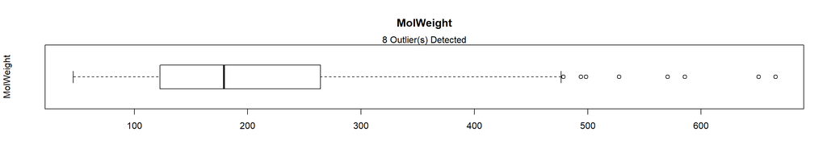

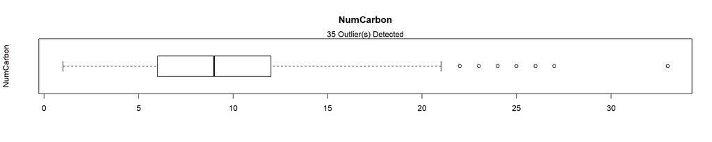

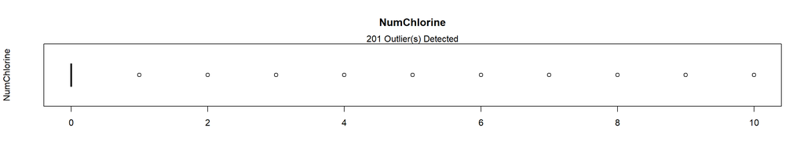

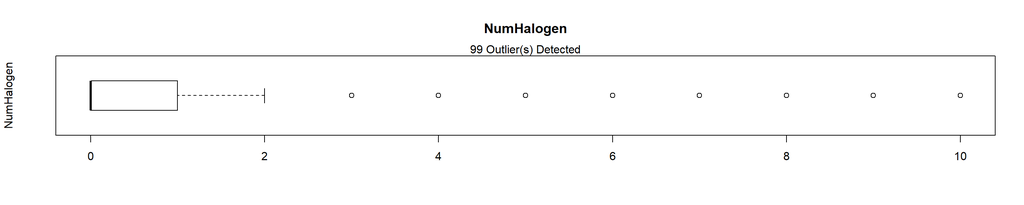

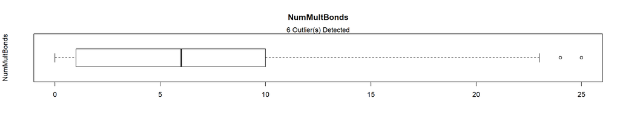

```r
##################################
# Loading dataset
##################################
DPA <- Solubility_Train

##################################
# Listing all predictors
##################################
DPA.Predictors <- DPA[,!names(DPA) %in% c("solTrainY")]

##################################
# Listing all numeric predictors
##################################
DPA.Predictors.Numeric <- DPA.Predictors[,sapply(DPA.Predictors, is.numeric)]

##################################
# Identifying outliers for the numeric predictors
##################################
OutlierCountList <- c()

for (i in 1:ncol(DPA.Predictors.Numeric)) {
  Outliers <- boxplot.stats(DPA.Predictors.Numeric[,i])$out
  OutlierCount <- length(Outliers)
  OutlierCountList <- append(OutlierCountList,OutlierCount)
  OutlierIndices <- which(DPA.Predictors.Numeric[,i] %in% c(Outliers))
  boxplot(DPA.Predictors.Numeric[,i],
          ylab = names(DPA.Predictors.Numeric)[i],
          main = names(DPA.Predictors.Numeric)[i],
          horizontal=TRUE)
  mtext(paste0(OutlierCount, " Outlier(s) Detected"))
}
```

```r
OutlierCountSummary <- as.data.frame(cbind(names(DPA.Predictors.Numeric),(OutlierCountList)))
names(OutlierCountSummary) <- c("NumericPredictors","OutlierCount")
OutlierCountSummary$OutlierCount <- as.numeric(as.character(OutlierCountSummary$OutlierCount))
NumericPredictorWithOutlierCount <- nrow(OutlierCountSummary[OutlierCountSummary$OutlierCount>0,])
print(paste0(NumericPredictorWithOutlierCount, " numeric variable(s) were noted with outlier(s)." ))
```

```
## [1] "5 numeric variable(s) were noted with outlier(s)."
```

```r
##################################
# Gathering descriptive statistics
##################################
(DPA_Skimmed <- skim(DPA.Predictors.Numeric))
```

Data summary

| Name | DPA.Predictors.Numeric |
| --- | --- |
| Number of rows | 951 |
| Number of columns | 5 |
| _______________________ |  |
| Column type frequency: |  |
| numeric | 5 |
| ________________________ |  |
| Group variables | None |

**Variable type: numeric**

| skim_variable | n_missing | complete_rate | mean | sd | p0 | p25 | p50 | p75 | p100 | hist |
| --- | --- | --- | --- | --- | --- | --- | --- | --- | --- | --- |
| MolWeight | 0 | 1 | 201.65 | 97.91 | 46.09 | 122.6 | 179.23 | 264.34 | 665.81 | ▇▆▂▁▁ |
| NumCarbon | 0 | 1 | 9.89 | 5.29 | 1.00 | 6.0 | 9.00 | 12.00 | 33.00 | ▇▇▃▁▁ |
| NumChlorine | 0 | 1 | 0.56 | 1.40 | 0.00 | 0.0 | 0.00 | 0.00 | 10.00 | ▇▁▁▁▁ |
| NumHalogen | 0 | 1 | 0.70 | 1.47 | 0.00 | 0.0 | 0.00 | 1.00 | 10.00 | ▇▁▁▁▁ |
| NumMultBonds | 0 | 1 | 6.15 | 5.17 | 0.00 | 1.0 | 6.00 | 10.00 | 25.00 | ▇▆▃▁▁ |

```r
###################################
# Verifying the data dimensions
###################################
dim(DPA.Predictors.Numeric)
```

```
## [1] 951   5
```

### 1.3.2 Zero and Near-Zero Variance

```r
##################################
# Loading dataset
##################################
DPA <- Solubility_Train

##################################
# Gathering descriptive statistics
##################################
(DPA_Skimmed <- skim(DPA))
```

Data summary

| Name | DPA |
| --- | --- |
| Number of rows | 951 |
| Number of columns | 6 |
| _______________________ |  |
| Column type frequency: |  |
| numeric | 6 |
| ________________________ |  |
| Group variables | None |

**Variable type: numeric**

| skim_variable | n_missing | complete_rate | mean | sd | p0 | p25 | p50 | p75 | p100 | hist |
| --- | --- | --- | --- | --- | --- | --- | --- | --- | --- | --- |
| solTrainY | 0 | 1 | -2.72 | 2.05 | -11.62 | -3.96 | -2.51 | -1.36 | 1.58 | ▁▁▃▇▃ |
| MolWeight | 0 | 1 | 201.65 | 97.91 | 46.09 | 122.60 | 179.23 | 264.34 | 665.81 | ▇▆▂▁▁ |
| NumCarbon | 0 | 1 | 9.89 | 5.29 | 1.00 | 6.00 | 9.00 | 12.00 | 33.00 | ▇▇▃▁▁ |
| NumChlorine | 0 | 1 | 0.56 | 1.40 | 0.00 | 0.00 | 0.00 | 0.00 | 10.00 | ▇▁▁▁▁ |
| NumHalogen | 0 | 1 | 0.70 | 1.47 | 0.00 | 0.00 | 0.00 | 1.00 | 10.00 | ▇▁▁▁▁ |
| NumMultBonds | 0 | 1 | 6.15 | 5.17 | 0.00 | 1.00 | 6.00 | 10.00 | 25.00 | ▇▆▃▁▁ |

```r
##################################
# Identifying columns with low variance
###################################
DPA_LowVariance <- nearZeroVar(DPA,
                               freqCut = 95/5,
                               uniqueCut = 10,
                               saveMetrics= TRUE)
(DPA_LowVariance[DPA_LowVariance$nzv,])
```

```
## [1] freqRatio     percentUnique zeroVar       nzv
## <0 rows> (or 0-length row.names)
```

```r
if ((nrow(DPA_LowVariance[DPA_LowVariance$nzv,]))==0){

  print("No low variance predictors noted.")

} else {

  print(paste0("Low variance observed for ",
               (nrow(DPA_LowVariance[DPA_LowVariance$nzv,])),
               " numeric variable(s) with First.Second.Mode.Ratio>4 and Unique.Count.Ratio<0.10."))

  DPA_LowVarianceForRemoval <- (nrow(DPA_LowVariance[DPA_LowVariance$nzv,]))

  print(paste0("Low variance can be resolved by removing ",
               (nrow(DPA_LowVariance[DPA_LowVariance$nzv,])),
               " numeric variable(s)."))

  for (j in 1:DPA_LowVarianceForRemoval) {
  DPA_LowVarianceRemovedVariable <- rownames(DPA_LowVariance[DPA_LowVariance$nzv,])[j]
  print(paste0("Variable ",
               j,
               " for removal: ",
               DPA_LowVarianceRemovedVariable))
  }

  DPA %>%
  skim() %>%
  dplyr::filter(skim_variable %in% rownames(DPA_LowVariance[DPA_LowVariance$nzv,]))

  ##################################
  # Filtering out columns with low variance
  #################################
  DPA_ExcludedLowVariance <- DPA[,!names(DPA) %in% rownames(DPA_LowVariance[DPA_LowVariance$nzv,])]

  ##################################
  # Gathering descriptive statistics
  ##################################
  (DPA_ExcludedLowVariance_Skimmed <- skim(DPA_ExcludedLowVariance))
}
```

```
## [1] "No low variance predictors noted."
```

### 1.3.3 Collinearity

High collinearity data assessment:  
**[A]** No high correlation > 95% were noted for any variable pair as confirmed using the preprocessing summaries from the **caret** and **lares** packages.

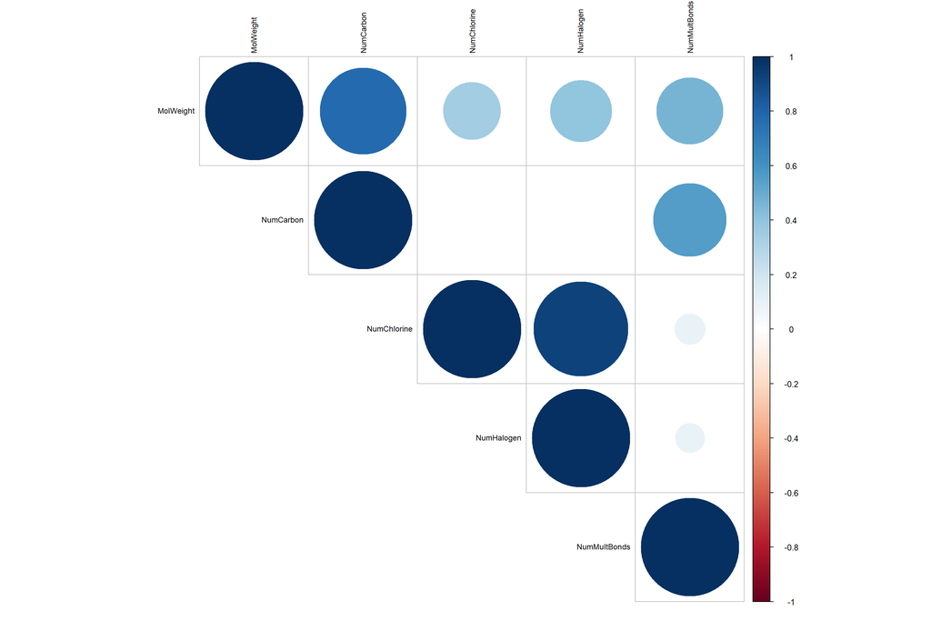

```r
##################################
# Loading dataset
##################################
DPA <- Solubility_Train

##################################
# Listing all predictors
##################################
DPA.Predictors <- DPA[,!names(DPA) %in% c("solTrainY")]

##################################
# Listing all numeric predictors
##################################
DPA.Predictors.Numeric <- DPA.Predictors[,sapply(DPA.Predictors, is.numeric)]

##################################
# Visualizing pairwise correlation between predictors
##################################
DPA_CorrelationTest <- cor.mtest(DPA.Predictors.Numeric,
                       method = "pearson",
                       conf.level = .95)

corrplot(cor(DPA.Predictors.Numeric,
             method = "pearson",
             use="pairwise.complete.obs"),
         method = "circle",
         type = "upper",
         order = "original",
         tl.col = "black",
         tl.cex = 0.75,
         tl.srt = 90,
         sig.level = 0.05,
         p.mat = DPA_CorrelationTest$p,
         insig = "blank")
```

```r
##################################
# Identifying the highly correlated variables
##################################
DPA_Correlation <-  cor(DPA.Predictors.Numeric,
                        method = "pearson",
                        use="pairwise.complete.obs")
(DPA_HighlyCorrelatedCount <- sum(abs(DPA_Correlation[upper.tri(DPA_Correlation)]) > 0.95))
```

```
## [1] 0
```

```r
if (DPA_HighlyCorrelatedCount == 0) {
  print("No highly correlated predictors noted.")
} else {
  print(paste0("High correlation observed for ",
               (DPA_HighlyCorrelatedCount),
               " pairs of numeric variable(s) with Correlation.Coefficient>0.95."))

  (DPA_HighlyCorrelatedPairs <- corr_cross(DPA.Predictors.Numeric,
  max_pvalue = 0.05,
  top = DPA_HighlyCorrelatedCount,
  rm.na = TRUE,
  grid = FALSE
))

}
```

```
## [1] "No highly correlated predictors noted."
```

```r
if (DPA_HighlyCorrelatedCount > 0) {
  DPA_HighlyCorrelated <- findCorrelation(DPA_Correlation, cutoff = 0.95)

  (DPA_HighlyCorrelatedForRemoval <- length(DPA_HighlyCorrelated))

  print(paste0("High correlation can be resolved by removing ",
               (DPA_HighlyCorrelatedForRemoval),
               " numeric variable(s)."))

  for (j in 1:DPA_HighlyCorrelatedForRemoval) {
  DPA_HighlyCorrelatedRemovedVariable <- colnames(DPA.Predictors.Numeric)[DPA_HighlyCorrelated[j]]
  print(paste0("Variable ",
               j,
               " for removal: ",
               DPA_HighlyCorrelatedRemovedVariable))
  }

  ##################################
  # Filtering out columns with high correlation
  #################################
  DPA_ExcludedHighCorrelation <- DPA[,-DPA_HighlyCorrelated]

  ##################################
  # Gathering descriptive statistics
  ##################################
  (DPA_ExcludedHighCorrelation_Skimmed <- skim(DPA_ExcludedHighCorrelation))

}
```

### 1.3.4 Linear Dependencies

Linear dependency data assessment:  
**[A]** No linear dependencies noted for any subset of variables using the preprocessing summary from the **caret** package applying the findLinearCombos method which utilizes the QR decomposition of a matrix to enumerate sets of linear combinations (if they exist).

```r
##################################
# Loading dataset
##################################
DPA <- Solubility_Train

##################################
# Listing all predictors
##################################
DPA.Predictors <- DPA[,!names(DPA) %in% c("solTrainY")]

##################################
# Listing all numeric predictors
##################################
DPA.Predictors.Numeric <- DPA.Predictors[,sapply(DPA.Predictors, is.numeric)]

##################################
# Identifying the linearly dependent variables
##################################
DPA_LinearlyDependent <- findLinearCombos(DPA.Predictors.Numeric)

(DPA_LinearlyDependentCount <- length(DPA_LinearlyDependent$linearCombos))
```

```
## [1] 0
```

```r
if (DPA_LinearlyDependentCount == 0) {
  print("No linearly dependent predictors noted.")
} else {
  print(paste0("Linear dependency observed for ",
               (DPA_LinearlyDependentCount),
               " subset(s) of numeric variable(s)."))

  for (i in 1:DPA_LinearlyDependentCount) {
    DPA_LinearlyDependentSubset <- colnames(DPA.Predictors.Numeric)[DPA_LinearlyDependent$linearCombos[[i]]]
    print(paste0("Linear dependent variable(s) for subset ",
                 i,
                 " include: ",
                 DPA_LinearlyDependentSubset))
  }

}
```

```
## [1] "No linearly dependent predictors noted."
```

```r
##################################
# Identifying the linearly dependent variables for removal
##################################

if (DPA_LinearlyDependentCount > 0) {
  DPA_LinearlyDependent <- findLinearCombos(DPA.Predictors.Numeric)

  DPA_LinearlyDependentForRemoval <- length(DPA_LinearlyDependent$remove)

  print(paste0("Linear dependency can be resolved by removing ",
               (DPA_LinearlyDependentForRemoval),
               " numeric variable(s)."))

  for (j in 1:DPA_LinearlyDependentForRemoval) {
  DPA_LinearlyDependentRemovedVariable <- colnames(DPA.Predictors.Numeric)[DPA_LinearlyDependent$remove[j]]
  print(paste0("Variable ",
               j,
               " for removal: ",
               DPA_LinearlyDependentRemovedVariable))
  }

  ##################################
  # Filtering out columns with linear dependency
  #################################
  DPA_ExcludedLinearlyDependent <- DPA[,-DPA_LinearlyDependent$remove]

  ##################################
  # Gathering descriptive statistics
  ##################################
  (DPA_ExcludedLinearlyDependent_Skimmed <- skim(DPA_ExcludedLinearlyDependent))

}
```

### 1.3.5 Shape Transformation

```r
##################################
# Loading dataset
##################################
DPA <- Solubility_Train

##################################
# Listing all predictors
##################################
DPA.Predictors <- DPA[,!names(DPA) %in% c("solTrainY")]

##################################
# Listing all numeric predictors
##################################
DPA.Predictors.Numeric <- DPA.Predictors[,sapply(DPA.Predictors, is.numeric)]

##################################
# Applying a Box-Cox transformation
##################################
DPA_BoxCox <- preProcess(DPA.Predictors.Numeric, method = c("BoxCox"))
DPA_BoxCoxTransformed <- predict(DPA_BoxCox, DPA.Predictors.Numeric)

##################################
# Gathering descriptive statistics
##################################
(DPA_BoxCoxTransformedSkimmed <- skim(DPA_BoxCoxTransformed))
```

Data summary

| Name | DPA_BoxCoxTransformed |
| --- | --- |
| Number of rows | 951 |
| Number of columns | 5 |
| _______________________ |  |
| Column type frequency: |  |
| numeric | 5 |
| ________________________ |  |
| Group variables | None |

**Variable type: numeric**

| skim_variable | n_missing | complete_rate | mean | sd | p0 | p25 | p50 | p75 | p100 | hist |
| --- | --- | --- | --- | --- | --- | --- | --- | --- | --- | --- |
| MolWeight | 0 | 1 | 5.19 | 0.48 | 3.83 | 4.81 | 5.19 | 5.58 | 6.50 | ▁▆▇▆▁ |
| NumCarbon | 0 | 1 | 3.54 | 1.34 | 0.00 | 2.62 | 3.52 | 4.25 | 7.62 | ▂▇▇▃▁ |
| NumChlorine | 0 | 1 | 0.56 | 1.40 | 0.00 | 0.00 | 0.00 | 0.00 | 10.00 | ▇▁▁▁▁ |
| NumHalogen | 0 | 1 | 0.70 | 1.47 | 0.00 | 0.00 | 0.00 | 1.00 | 10.00 | ▇▁▁▁▁ |
| NumMultBonds | 0 | 1 | 6.15 | 5.17 | 0.00 | 1.00 | 6.00 | 10.00 | 25.00 | ▇▆▃▁▁ |

```r
###################################
# Verifying the data dimensions
###################################
dim(DPA_BoxCoxTransformed)
```

```
## [1] 951   5
```

### 1.3.6 Centering and Scaling

Centering and scaling data assessment:  
**[A]** To maintain numerical stability during modelling, centering and scaling transformations were applied on the transformed numeric variables. The center method from the **caret** package was implemented which subtracts the average value of a numeric variable to all the values. As a result of centering, the variables had zero mean values. In addition, the scale method, also from the **caret** package, was applied which performs a center transformation with each value of the variable divided by its standard deviation. Scaling the data coerced the values to have a common standard deviation of one.

```r
##################################
# Loading dataset
##################################
DPA <- Solubility_Train

##################################
# Listing all predictors
##################################
DPA.Predictors <- DPA[,!names(DPA) %in% c("solTrainY")]

##################################
# Listing all numeric predictors
##################################
DPA.Predictors.Numeric <- DPA.Predictors[,sapply(DPA.Predictors, is.numeric)]

##################################
# Applying a Box-Cox transformation
##################################
DPA_BoxCox <- preProcess(DPA.Predictors.Numeric, method = c("BoxCox"))
DPA_BoxCoxTransformed <- predict(DPA_BoxCox, DPA.Predictors.Numeric)

##################################
# Applying a center and scale data transformation
##################################
DPA.Predictors.Numeric_BoxCoxTransformed_CenteredScaled <- preProcess(DPA_BoxCoxTransformed, method = c("center","scale"))
DPA.Predictors.Numeric_BoxCoxTransformed_CenteredScaledTransformed <- predict(DPA.Predictors.Numeric_BoxCoxTransformed_CenteredScaled, DPA_BoxCoxTransformed)

##################################
# Gathering descriptive statistics
##################################
(DPA.Predictors.Numeric_BoxCoxTransformed_CenteredScaledTransformedSkimmed <- skim(DPA.Predictors.Numeric_BoxCoxTransformed_CenteredScaledTransformed))
```

Data summary

| Name | DPA.Predictors.Numeric_Bo… |
| --- | --- |
| Number of rows | 951 |
| Number of columns | 5 |
| _______________________ |  |
| Column type frequency: |  |
| numeric | 5 |
| ________________________ |  |
| Group variables | None |

**Variable type: numeric**

| skim_variable | n_missing | complete_rate | mean | sd | p0 | p25 | p50 | p75 | p100 | hist |
| --- | --- | --- | --- | --- | --- | --- | --- | --- | --- | --- |
| MolWeight | 0 | 1 | 0 | 1 | -2.84 | -0.80 | -0.01 | 0.80 | 2.72 | ▁▆▇▆▁ |
| NumCarbon | 0 | 1 | 0 | 1 | -2.64 | -0.69 | -0.01 | 0.54 | 3.06 | ▂▇▇▃▁ |
| NumChlorine | 0 | 1 | 0 | 1 | -0.40 | -0.40 | -0.40 | -0.40 | 6.74 | ▇▁▁▁▁ |
| NumHalogen | 0 | 1 | 0 | 1 | -0.47 | -0.47 | -0.47 | 0.20 | 6.32 | ▇▁▁▁▁ |
| NumMultBonds | 0 | 1 | 0 | 1 | -1.19 | -1.00 | -0.03 | 0.74 | 3.65 | ▇▇▃▁▁ |

```r
###################################
# Verifying the data dimensions
###################################
dim(DPA.Predictors.Numeric_BoxCoxTransformed_CenteredScaledTransformed)
```

```
## [1] 951   5
```

### 1.3.7 Pre-Processed Dataset

Preliminary dataset assessment:  
**[A]** 951 rows (observations)  
**[A.1]** Train Set = 951 observations  
**[B]** 6 columns (variables)  
**[B.1]** 1/6 response = Log_Solubility variable (numeric)  
**[B.2]** 5/6 predictors = All remaining variables (0/5 factor + 5/5 numeric)  
**[C]** Pre-processing actions applied:  
**[C.1]** Centering, scaling and shape transformation applied to improve data quality  
**[C.2]** No outlier treatment applied since the high values noted were contextually valid and sensible  
**[C.3]** No predictors removed due to zero or near-zero variance  
**[C.4]** No predictors removed due to high correlation  
**[C.5]** No predictors removed due to linear dependencies

```r
##################################
# Creating the pre-modelling
# train set
##################################
Log_Solubility <- DPA$solTrainY
PMA.Predictors.Numeric  <- DPA.Predictors.Numeric_BoxCoxTransformed_CenteredScaledTransformed
PMA_BoxCoxTransformed_CenteredScaledTransformed <- cbind(Log_Solubility,PMA.Predictors.Numeric)
PMA_PreModelling_Train <- PMA_BoxCoxTransformed_CenteredScaledTransformed

##################################
# Gathering descriptive statistics
##################################
(PMA_PreModelling_Train_Skimmed <- skim(PMA_PreModelling_Train))
```

Data summary

| Name | PMA_PreModelling_Train |
| --- | --- |
| Number of rows | 951 |
| Number of columns | 6 |
| _______________________ |  |
| Column type frequency: |  |
| numeric | 6 |
| ________________________ |  |
| Group variables | None |

**Variable type: numeric**

| skim_variable | n_missing | complete_rate | mean | sd | p0 | p25 | p50 | p75 | p100 | hist |
| --- | --- | --- | --- | --- | --- | --- | --- | --- | --- | --- |
| Log_Solubility | 0 | 1 | -2.72 | 2.05 | -11.62 | -3.96 | -2.51 | -1.36 | 1.58 | ▁▁▃▇▃ |
| MolWeight | 0 | 1 | 0.00 | 1.00 | -2.84 | -0.80 | -0.01 | 0.80 | 2.72 | ▁▆▇▆▁ |
| NumCarbon | 0 | 1 | 0.00 | 1.00 | -2.64 | -0.69 | -0.01 | 0.54 | 3.06 | ▂▇▇▃▁ |
| NumChlorine | 0 | 1 | 0.00 | 1.00 | -0.40 | -0.40 | -0.40 | -0.40 | 6.74 | ▇▁▁▁▁ |
| NumHalogen | 0 | 1 | 0.00 | 1.00 | -0.47 | -0.47 | -0.47 | 0.20 | 6.32 | ▇▁▁▁▁ |
| NumMultBonds | 0 | 1 | 0.00 | 1.00 | -1.19 | -1.00 | -0.03 | 0.74 | 3.65 | ▇▇▃▁▁ |

```r
###################################
# Verifying the data dimensions
# for the train set
###################################
dim(PMA_PreModelling_Train)
```

```
## [1] 951   6
```

## 1.4 Data Exploration

Exploratory data analysis:  
**[A]** The numeric variables demonstrated linear or non-linear relationships with the Log_Solubility response variable:  
**[A.1]** MolWeight variable (numeric)  
**[A.2]** NumCarbon variable (numeric)  
**[A.3]** NumChlorine variable (numeric)  
**[A.4]** NumHalogen variable (numeric)  
**[A.5]** NumMultBonds variable (numeric)

```r
##################################
# Loading dataset
##################################
EDA <- PMA_PreModelling_Train

##################################
# Listing all predictors
##################################
EDA.Predictors <- EDA[,!names(EDA) %in% c("Log_Solubility")]

##################################
# Listing all numeric predictors
##################################
EDA.Predictors.Numeric <- EDA.Predictors[,sapply(EDA.Predictors, is.numeric)]
ncol(EDA.Predictors.Numeric)
```

```
## [1] 5
```

```r
names(EDA.Predictors.Numeric)
```

```
## [1] "MolWeight"    "NumCarbon"    "NumChlorine"  "NumHalogen"   "NumMultBonds"
```

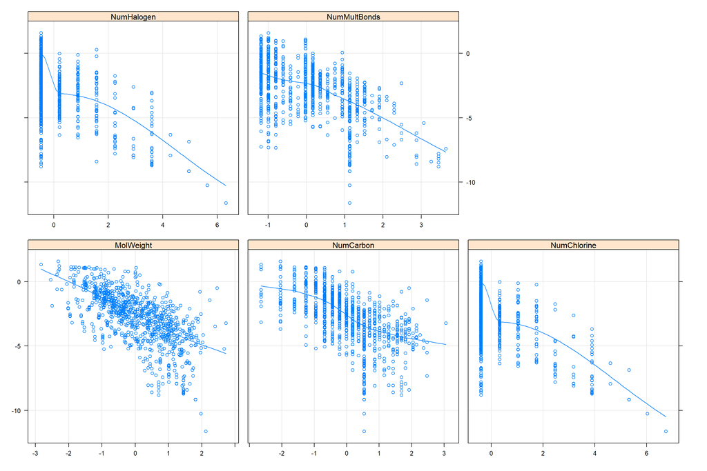

```r
##################################
# Formulating the scatter plots
##################################
featurePlot(x = EDA.Predictors.Numeric,
            y = EDA$Log_Solubility,
            between = list(x = 1, y = 1),
            type = c("g", "p", "smooth"),
            labels = rep("", 2))
```

## 1.5 Linear Regression Model Coefficient Estimation

### 1.5.1 Linear Regression - Normal Equations (LR_NE)

**[A]** Applying normal equations, the estimated linear regression coefficients for the given data are as follows:  
**[A.1]** Intercept = -2.71856  
**[A.2]** MolWeight = +0.20493  
**[A.3]** NumCarbon = -1.25425  
**[A.4]** NumChlorine = -0.14419  
**[A.5]** NumHalogen = -1.01350  
**[A.6]** NumMultBonds = -0.33048  
**[B]** These estimated coefficients will be the baseline values from which all gradient descent algorithm-derived coefficients will be compared with.

```r
##################################
# Defining a function to implement
# normal equations for estimating
# linear regression coefficients
##################################
NormalEquations_LREstimation <- function(y, X){
  X = data.frame(rep(1,length(y)),X)
  X = as.matrix(X)
  LRcoefficients = solve(t(X)%*%X)%*%t(X)%*%y
  return(LRcoefficients)
}

##################################
# Loading dataset
# and restructuring to the
# y and X components
##################################
y               <- PMA_PreModelling_Train$Log_Solubility
x1_MolWeight    <- PMA_PreModelling_Train$MolWeight
x2_NumCarbon    <- PMA_PreModelling_Train$NumCarbon
x3_NumChlorine  <- PMA_PreModelling_Train$NumChlorine
x4_NumHalogen   <- PMA_PreModelling_Train$NumHalogen
x5_NumMultBonds <- PMA_PreModelling_Train$NumMultBonds
X = data.frame(x1_MolWeight,
               x2_NumCarbon,
               x3_NumChlorine,
               x4_NumHalogen,
               x5_NumMultBonds)

##################################
# Estimating the linear regression coefficients
# using the normal equations algorithm
##################################
LR_NE <- NormalEquations_LREstimation(y = y,
                                      X = X)

##################################
# Consolidating all estimated
# linear regression coefficients
# using the normal equations algorithm
##################################
LR_NE <- as.data.frame(LR_NE)
rownames(LR_NE) <- NULL
colnames(LR_NE) <- c("LRCoefficients")
LR_NE$LRCoefficientNames <- c("Intercept",
                              "MolWeight",
                              "NumCarbon",
                              "NumChlorine",
                              "NumHalogen",
                              "NumMultBonds")
LR_NE$EstimationMethod <- rep("LR_NE",nrow(LR_NE))

##################################
# Summarizing the estimated
# linear regression coefficients
# using the normal equations algorithm
##################################
print(LR_NE)
```

```
##   LRCoefficients LRCoefficientNames EstimationMethod
## 1     -2.7185699          Intercept            LR_NE
## 2      0.2049318          MolWeight            LR_NE
## 3     -1.2542520          NumCarbon            LR_NE
## 4     -0.1441934        NumChlorine            LR_NE
## 5     -1.0135099         NumHalogen            LR_NE
## 6     -0.3304828       NumMultBonds            LR_NE
```

### 1.5.2 Linear Regression - Gradient Descent Algorithm with Very High Learning Rate and Low Epoch Count (LR_GDA_VHLR_LEC)

```r
##################################
# Defining a function to implement
# gradient descent algorithm for estimating
# linear regression coefficients
##################################
GradientDescent_LREstimation <-function(y, X, GradientNormMinimumThreshold, LearningRate, Epochs){
  GradientNormMinimumThreshold = 0.0001
  X = as.matrix(data.frame(rep(1,length(y)),X))
  N= dim(X)[1]
  print("Initializing Gradient Descent Algorithm Parameters.")
  set.seed(12345678)
  Theta.InitialValue = as.matrix(rnorm(n=dim(X)[2], mean=0,sd = 1))
  Theta.InitialValue = t(Theta.InitialValue)
  e = t(y) - Theta.InitialValue%*%t(X)
  Gradient.InitialValue = -(2/N)%*%(e)%*%X
  Theta = Theta.InitialValue - LearningRate *(1/N)*Gradient.InitialValue
  L2Loss = c()
  for(i in 1:Epochs){
    L2Loss = c(L2Loss,sqrt(sum((t(y) - Theta%*%t(X))^2)))
    e = t(y) - Theta%*%t(X)
    grad = -(2/N)%*%e%*%X
    Theta = Theta - LearningRate*(2/N)*grad
    if(sqrt(sum(grad^2)) <= GradientNormMinimumThreshold){
      break
    }
  }
  if (i < Epochs) {
    print("Gradient Descent Algorithm Converged.")
  }
  if (i == Epochs) {
    print("Gradient Descent Algorithm Reached Last Epoch Without Convergence.")
    print("Minimum Threshold for Gradient Norm = 0.0001 Not Achieved.")
  }
  print(paste("Final Gradient Norm Determined as ",sqrt(sum(grad^2)),"at Epoch",i))
  GradientDescentAlgorithmValues <- list("LRCoefficients" = t(Theta), "L2Loss" = L2Loss)
  return(GradientDescentAlgorithmValues)
}

##################################
# Estimating the linear regression coefficients
# using the gradient descent algorithm
# with very high learning rate and low epoch count
##################################
LR_GDA_VHLR_LEC = GradientDescent_LREstimation(y = y,
                                          X = X,
                                          LearningRate = 200,
                                          Epochs = 10)
```

```
## [1] "Initializing Gradient Descent Algorithm Parameters."
## [1] "Gradient Descent Algorithm Reached Last Epoch Without Convergence."
## [1] "Minimum Threshold for Gradient Norm = 0.0001 Not Achieved."
## [1] "Final Gradient Norm Determined as  0.42670603153189 at Epoch 10"
```

```r
LR_GDA_VHLR_LEC_Summary <- LR_GDA_VHLR_LEC

##################################
# Consolidating all estimated
# linear regression coefficients
# using the gradient descent algorithm
# with very high learning rate and low epoch count
##################################
LR_GDA_VHLR_LEC <- as.data.frame(LR_GDA_VHLR_LEC_Summary$LRCoefficients)
rownames(LR_GDA_VHLR_LEC) <- NULL
colnames(LR_GDA_VHLR_LEC) <- c("LRCoefficients")
LR_GDA_VHLR_LEC$LRCoefficientNames <- c("Intercept",
                                   "MolWeight",
                                   "NumCarbon",
                                   "NumChlorine",
                                   "NumHalogen",
                                   "NumMultBonds")
LR_GDA_VHLR_LEC$EstimationMethod <- rep("LR_GDA_VHLR_LEC",nrow(LR_GDA_VHLR_LEC))

##################################
# Summarizing the estimated
# linear regression coefficients
# using the gradient descent algorithm
# with very high learning rate and low epoch count
##################################
print(LR_GDA_VHLR_LEC)
```

```
##   LRCoefficients LRCoefficientNames EstimationMethod
## 1     -2.7185699          Intercept  LR_GDA_VHLR_LEC
## 2      0.2684003          MolWeight  LR_GDA_VHLR_LEC
## 3     -1.4126207          NumCarbon  LR_GDA_VHLR_LEC
## 4     -0.6009731        NumChlorine  LR_GDA_VHLR_LEC
## 5     -0.6815776         NumHalogen  LR_GDA_VHLR_LEC
## 6     -0.3415085       NumMultBonds  LR_GDA_VHLR_LEC
```

```r
##################################
# Gathering the cost function optimization data
# for the gradient descent algorithm
# with very high learning rate and low epoch count
##################################
LR_GDA_VHLR_LEC_Summary$Epoch <- 1:length(LR_GDA_VHLR_LEC_Summary$L2Loss)
LR_GDA_VHLR_LEC_Summary$Method <- rep("LR_GDA_VHLR_LEC",length(LR_GDA_VHLR_LEC_Summary$L2Loss))

L2Loss <- LR_GDA_VHLR_LEC_Summary$L2Loss
Epoch  <- LR_GDA_VHLR_LEC_Summary$Epoch
Method <- LR_GDA_VHLR_LEC_Summary$Method
(LR_GDA_VHLR_LEC_ConsolidatedSummary <- cbind(L2Loss, Epoch, Method))
```

```
##       L2Loss             Epoch Method
##  [1,] "82.9563953049771" "1"   "LR_GDA_VHLR_LEC"
##  [2,] "43.3675127878632" "2"   "LR_GDA_VHLR_LEC"
##  [3,] "40.1055331895743" "3"   "LR_GDA_VHLR_LEC"
##  [4,] "38.9740740659105" "4"   "LR_GDA_VHLR_LEC"
##  [5,] "38.2468234561932" "5"   "LR_GDA_VHLR_LEC"
##  [6,] "37.7326021491187" "6"   "LR_GDA_VHLR_LEC"
##  [7,] "37.3604396276862" "7"   "LR_GDA_VHLR_LEC"
##  [8,] "37.0910709007472" "8"   "LR_GDA_VHLR_LEC"
##  [9,] "36.8989019283906" "9"   "LR_GDA_VHLR_LEC"
## [10,] "36.7660015463775" "10"  "LR_GDA_VHLR_LEC"
```

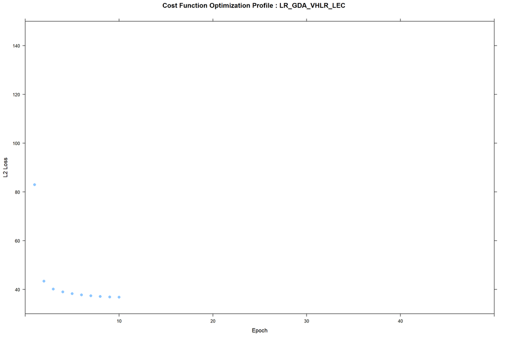

```r
##################################
# Plotting the cost function optimization data
# for the gradient descent algorithm
# with very high learning rate and low epoch count
##################################
xyplot(L2Loss ~ Epoch,
       data = LR_GDA_VHLR_LEC_Summary,
       main = "Cost Function Optimization Profile : LR_GDA_VHLR_LEC",
       ylab = "L2 Loss",
       xlab = "Epoch",
       type=c("p"),
       origin = 0,
       alpha = 0.45,
       pch = 16,
       cex = 1,
       xlim = c(0, 50),
       ylim = c(30, 150))
```

### 1.5.3 Linear Regression - Gradient Descent Algorithm with Very High Learning Rate and High Epoch Count (LR_GDA_VHLR_HEC)

**[A]** The gradient descent algorithm was implemented with parameter settings described as follows:  
**[A.1]** Learning Rate = 200 (Very High)  
**[A.2]** Epochs = 50 (High)  
**[B]** The final gradient norm was determined as 11.84773 at the 50th epoch indicating that the minimum threshold of 0.00010 was not achieved prior to the last epoch.  
**[C]** Applying the gradient descent algorithm with a high learning rate and high epoch count, the estimated linear regression coefficients for the given data are as follows:  
**[C.1]** Intercept = -2.71857 (Baseline = -2.71856)  
**[C.2]** MolWeight = -1.26942 (Baseline = +0.20493)  
**[C.3]** NumCarbon = -2.36919 (Baseline = -1.25425)  
**[C.4]** NumChlorine = -1.21815 (Baseline = -0.14419)  
**[C.5]** NumHalogen = -2.00242 (Baseline = -1.01350)  
**[C.6]** NumMultBonds = -1.42725 (Baseline = -0.33048)  
**[D]** The estimated coefficients using the gradient descent algorithm with a very high learning rate and high epoch count were not fully optimized and were not comparable with the baseline coefficients using normal equations.

```r
##################################
# Estimating the linear regression coefficients
# using the gradient descent algorithm
# with very high learning rate and high epoch count
##################################
LR_GDA_VHLR_HEC = GradientDescent_LREstimation(y = y,
                                          X = X,
                                          LearningRate = 200,
                                          Epochs = 50)
```

```
## [1] "Initializing Gradient Descent Algorithm Parameters."
## [1] "Gradient Descent Algorithm Reached Last Epoch Without Convergence."
## [1] "Minimum Threshold for Gradient Norm = 0.0001 Not Achieved."
## [1] "Final Gradient Norm Determined as  11.8477388521046 at Epoch 50"
```

```r
LR_GDA_VHLR_HEC_Summary <- LR_GDA_VHLR_HEC

##################################
# Consolidating all estimated
# linear regression coefficients
# using the gradient descent algorithm
# with very high learning rate and high epoch count
##################################
LR_GDA_VHLR_HEC <- as.data.frame(LR_GDA_VHLR_HEC_Summary$LRCoefficients)
rownames(LR_GDA_VHLR_HEC) <- NULL
colnames(LR_GDA_VHLR_HEC) <- c("LRCoefficients")
LR_GDA_VHLR_HEC$LRCoefficientNames <- c("Intercept",
                                   "MolWeight",
                                   "NumCarbon",
                                   "NumChlorine",
                                   "NumHalogen",
                                   "NumMultBonds")
LR_GDA_VHLR_HEC$EstimationMethod <- rep("LR_GDA_VHLR_HEC",nrow(LR_GDA_VHLR_HEC))

##################################
# Summarizing the estimated
# linear regression coefficients
# using the gradient descent algorithm
# with very high learning rate and high epoch count
##################################
print(LR_GDA_VHLR_HEC)
```

```
##   LRCoefficients LRCoefficientNames EstimationMethod
## 1      -2.718570          Intercept  LR_GDA_VHLR_HEC
## 2      -1.269429          MolWeight  LR_GDA_VHLR_HEC
## 3      -2.369198          NumCarbon  LR_GDA_VHLR_HEC
## 4      -1.218151        NumChlorine  LR_GDA_VHLR_HEC
## 5      -2.002425         NumHalogen  LR_GDA_VHLR_HEC
## 6      -1.427259       NumMultBonds  LR_GDA_VHLR_HEC
```

```r
##################################
# Gathering the cost function optimization data
# for the gradient descent algorithm
# with very high learning rate and high epoch count
##################################
LR_GDA_VHLR_HEC_Summary$Epoch <- 1:length(LR_GDA_VHLR_HEC_Summary$L2Loss)
LR_GDA_VHLR_HEC_Summary$Method <- rep("LR_GDA_VHLR_HEC",length(LR_GDA_VHLR_HEC_Summary$L2Loss))

L2Loss <- LR_GDA_VHLR_HEC_Summary$L2Loss
Epoch  <- LR_GDA_VHLR_HEC_Summary$Epoch
Method <- LR_GDA_VHLR_HEC_Summary$Method
(LR_GDA_VHLR_HEC_ConsolidatedSummary <- cbind(L2Loss, Epoch, Method))
```

```
##       L2Loss             Epoch Method
##  [1,] "82.9563953049771" "1"   "LR_GDA_VHLR_HEC"
##  [2,] "43.3675127878632" "2"   "LR_GDA_VHLR_HEC"
##  [3,] "40.1055331895743" "3"   "LR_GDA_VHLR_HEC"
##  [4,] "38.9740740659105" "4"   "LR_GDA_VHLR_HEC"
##  [5,] "38.2468234561932" "5"   "LR_GDA_VHLR_HEC"
##  [6,] "37.7326021491187" "6"   "LR_GDA_VHLR_HEC"
##  [7,] "37.3604396276862" "7"   "LR_GDA_VHLR_HEC"
##  [8,] "37.0910709007472" "8"   "LR_GDA_VHLR_HEC"
##  [9,] "36.8989019283906" "9"   "LR_GDA_VHLR_HEC"
## [10,] "36.7660015463775" "10"  "LR_GDA_VHLR_HEC"
## [11,] "36.6795350594859" "11"  "LR_GDA_VHLR_HEC"
## [12,] "36.6303695815112" "12"  "LR_GDA_VHLR_HEC"
## [13,] "36.612173832238"  "13"  "LR_GDA_VHLR_HEC"
## [14,] "36.620787212362"  "14"  "LR_GDA_VHLR_HEC"
```

[output cut: 36 more lines]

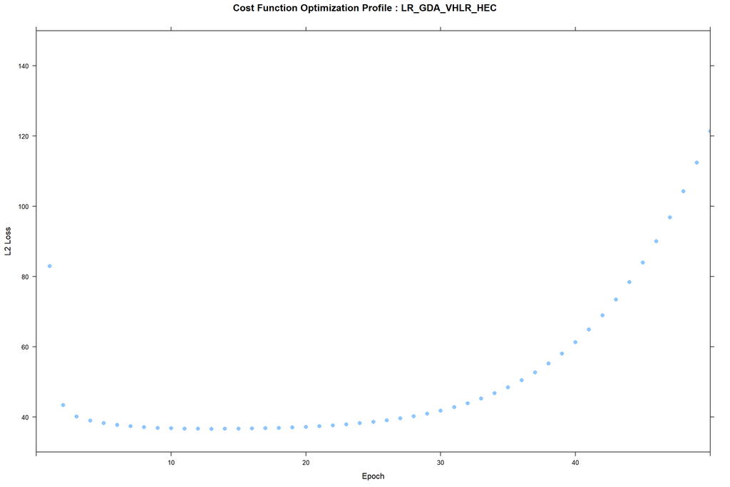

```r
##################################
# Plotting the cost function optimization data
# for the gradient descent algorithm
# with very high learning rate and high epoch count
##################################
xyplot(L2Loss ~ Epoch,
       data = LR_GDA_VHLR_HEC_Summary,
       main = "Cost Function Optimization Profile : LR_GDA_VHLR_HEC",
       ylab = "L2 Loss",
       xlab = "Epoch",
       type=c("p"),
       origin = 0,
       alpha = 0.45,
       pch = 16,
       cex = 1,
       xlim = c(0, 50),
       ylim = c(30, 150))
```

### 1.5.4 Linear Regression - Gradient Descent Algorithm with High Learning Rate and Low Epoch Count (LR_GDA_HLR_LEC)

**[A]** The gradient descent algorithm was implemented with parameter settings described as follows:  
**[A.1]** Learning Rate = 100 (High)  
**[A.2]** Epochs = 10 (Low)  
**[B]** The final gradient norm was determined as 0.32722 at the 10th epoch indicating that the minimum threshold of 0.00010 was not achieved up until the last epoch.  
**[C]** Applying the gradient descent algorithm with a high learning rate and low epoch count, the estimated linear regression coefficients for the given data are as follows:  
**[C.1]** Intercept = -2.70555 (Baseline = -2.71856)  
**[C.2]** MolWeight = +0.60475 (Baseline = +0.20493)  
**[C.3]** NumCarbon = -1.63634 (Baseline = -1.25425)  
**[C.4]** NumChlorine = -0.84899 (Baseline = -0.14419)  
**[C.5]** NumHalogen = -0.49265 (Baseline = -1.01350)  
**[C.6]** NumMultBonds = -0.29582 (Baseline = -0.33048)  
**[D]** The estimated coefficients using the gradient descent algorithm with a high learning rate and low epoch count were not fully optimized and were not comparable with the baseline coefficients using normal equations.

```r
##################################
# Estimating the linear regression coefficients
# using the gradient descent algorithm
# with high learning rate and low epoch count
##################################
LR_GDA_HLR_LEC = GradientDescent_LREstimation(y = y,
                                          X = X,
                                          LearningRate = 100,
                                          Epochs = 10)
```

```
## [1] "Initializing Gradient Descent Algorithm Parameters."
## [1] "Gradient Descent Algorithm Reached Last Epoch Without Convergence."
## [1] "Minimum Threshold for Gradient Norm = 0.0001 Not Achieved."
## [1] "Final Gradient Norm Determined as  0.327225250712014 at Epoch 10"
```

```r
LR_GDA_HLR_LEC_Summary <- LR_GDA_HLR_LEC

##################################
# Consolidating all estimated
# linear regression coefficients
# using the gradient descent algorithm
# with high learning rate and low epoch count
##################################
LR_GDA_HLR_LEC <- as.data.frame(LR_GDA_HLR_LEC_Summary$LRCoefficients)
rownames(LR_GDA_HLR_LEC) <- NULL
colnames(LR_GDA_HLR_LEC) <- c("LRCoefficients")
LR_GDA_HLR_LEC$LRCoefficientNames <- c("Intercept",
                                   "MolWeight",
                                   "NumCarbon",
                                   "NumChlorine",
                                   "NumHalogen",
                                   "NumMultBonds")
LR_GDA_HLR_LEC$EstimationMethod <- rep("LR_GDA_HLR_LEC",nrow(LR_GDA_HLR_LEC))

##################################
# Summarizing the estimated
# linear regression coefficients
# using the gradient descent algorithm
# with high learning rate and low epoch count
##################################
print(LR_GDA_HLR_LEC)
```

```
##   LRCoefficients LRCoefficientNames EstimationMethod
## 1     -2.7055537          Intercept   LR_GDA_HLR_LEC
## 2      0.6047579          MolWeight   LR_GDA_HLR_LEC
## 3     -1.6363423          NumCarbon   LR_GDA_HLR_LEC
## 4     -0.8489932        NumChlorine   LR_GDA_HLR_LEC
## 5     -0.4926584         NumHalogen   LR_GDA_HLR_LEC
## 6     -0.2958283       NumMultBonds   LR_GDA_HLR_LEC
```

```r
##################################
# Gathering the cost function optimization data
# for the gradient descent algorithm
# with high learning rate and low epoch count
##################################
LR_GDA_HLR_LEC_Summary$Epoch <- 1:length(LR_GDA_HLR_LEC_Summary$L2Loss)
LR_GDA_HLR_LEC_Summary$Method <- rep("LR_GDA_HLR_LEC",length(LR_GDA_HLR_LEC_Summary$L2Loss))

L2Loss <- LR_GDA_HLR_LEC_Summary$L2Loss
Epoch  <- LR_GDA_HLR_LEC_Summary$Epoch
Method <- LR_GDA_HLR_LEC_Summary$Method
(LR_GDA_HLR_LEC_ConsolidatedSummary <- cbind(L2Loss, Epoch, Method))
```

```
##       L2Loss             Epoch Method
##  [1,] "112.129202156293" "1"   "LR_GDA_HLR_LEC"
##  [2,] "69.9906053294776" "2"   "LR_GDA_HLR_LEC"
##  [3,] "52.4658187984899" "3"   "LR_GDA_HLR_LEC"
##  [4,] "44.8755235067431" "4"   "LR_GDA_HLR_LEC"
##  [5,] "41.6408804372354" "5"   "LR_GDA_HLR_LEC"
##  [6,] "40.1564841713508" "6"   "LR_GDA_HLR_LEC"
##  [7,] "39.3527407791219" "7"   "LR_GDA_HLR_LEC"
##  [8,] "38.8275066395866" "8"   "LR_GDA_HLR_LEC"
##  [9,] "38.4326912660602" "9"   "LR_GDA_HLR_LEC"
## [10,] "38.1117947361666" "10"  "LR_GDA_HLR_LEC"
```

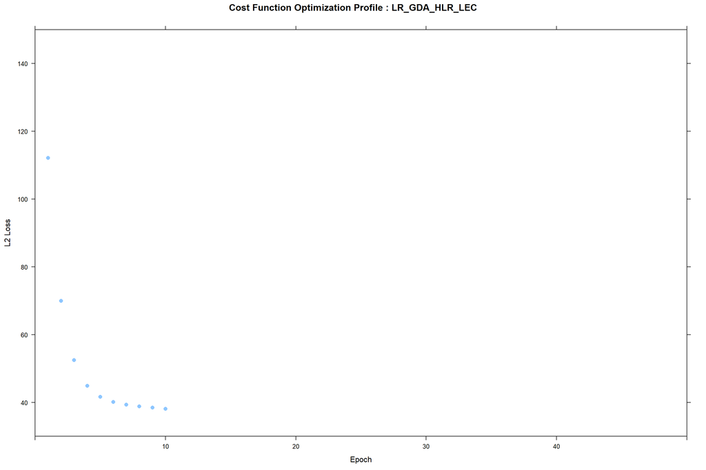

```r
##################################
# Plotting the cost function optimization data
# for the gradient descent algorithm
# with high learning rate and low epoch count
##################################
xyplot(L2Loss ~ Epoch,
       data = LR_GDA_HLR_LEC_Summary,
       main = "Cost Function Optimization Profile : LR_GDA_HLR_LEC",
       ylab = "L2 Loss",
       xlab = "Epoch",
       type=c("p"),
       origin = 0,
       alpha = 0.45,
       pch = 16,
       cex = 1,
       xlim = c(0, 50),
       ylim = c(30, 150))
```

### 1.5.5 Linear Regression - Gradient Descent Algorithm with High Learning Rate and High Epoch Count (LR_GDA_HLR_HEC)

**[A]** The gradient descent algorithm was implemented with parameter settings described as follows:  
**[A.1]** Learning Rate = 100 (High)  
**[A.2]** Epochs = 50 (High)  
**[B]** The final gradient norm was determined as 0.03004 at the 50th epoch indicating that the minimum threshold of 0.00010 was not achieved prior to the last epoch.  
**[C]** Applying the gradient descent algorithm with a high learning rate and high epoch count, the estimated linear regression coefficients for the given data are as follows:  
**[C.1]** Intercept = -2.71856 (Baseline = -2.71856)  
**[C.2]** MolWeight = +0.16985 (Baseline = +0.20493)  
**[C.3]** NumCarbon = -1.22196 (Baseline = -1.25425)  
**[C.4]** NumChlorine = -0.29779 (Baseline = -0.14419)  
**[C.5]** NumHalogen = -0.84627 (Baseline = -1.01350)  
**[C.6]** NumMultBonds = -0.33109 (Baseline = -0.33048)  
**[D]** The estimated coefficients using the gradient descent algorithm with a high learning rate and high epoch count, while not fully optimized, were sufficiently comparable with the baseline coefficients using normal equations.

```r
##################################
# Estimating the linear regression coefficients
# using the gradient descent algorithm
# with high learning rate and high epoch count
##################################
LR_GDA_HLR_HEC = GradientDescent_LREstimation(y = y,
                                          X = X,
                                          LearningRate = 100,
                                          Epochs = 50)
```

```
## [1] "Initializing Gradient Descent Algorithm Parameters."
## [1] "Gradient Descent Algorithm Reached Last Epoch Without Convergence."
## [1] "Minimum Threshold for Gradient Norm = 0.0001 Not Achieved."
## [1] "Final Gradient Norm Determined as  0.0300496286624375 at Epoch 50"
```

```r
LR_GDA_HLR_HEC_Summary <- LR_GDA_HLR_HEC

##################################
# Consolidating all estimated
# linear regression coefficients
# using the gradient descent algorithm
# with high learning rate and high epoch count
##################################
LR_GDA_HLR_HEC <- as.data.frame(LR_GDA_HLR_HEC_Summary$LRCoefficients)
rownames(LR_GDA_HLR_HEC) <- NULL
colnames(LR_GDA_HLR_HEC) <- c("LRCoefficients")
LR_GDA_HLR_HEC$LRCoefficientNames <- c("Intercept",
                                   "MolWeight",
                                   "NumCarbon",
                                   "NumChlorine",
                                   "NumHalogen",
                                   "NumMultBonds")
LR_GDA_HLR_HEC$EstimationMethod <- rep("LR_GDA_HLR_HEC",nrow(LR_GDA_HLR_HEC))

##################################
# Summarizing the estimated
# linear regression coefficients
# using the gradient descent algorithm
# with high learning rate and high epoch count
##################################
print(LR_GDA_HLR_HEC)
```

```
##   LRCoefficients LRCoefficientNames EstimationMethod
## 1     -2.7185699          Intercept   LR_GDA_HLR_HEC
## 2      0.1698594          MolWeight   LR_GDA_HLR_HEC
## 3     -1.2219687          NumCarbon   LR_GDA_HLR_HEC
## 4     -0.2977972        NumChlorine   LR_GDA_HLR_HEC
## 5     -0.8462708         NumHalogen   LR_GDA_HLR_HEC
## 6     -0.3310979       NumMultBonds   LR_GDA_HLR_HEC
```

```r
##################################
# Gathering the cost function optimization data
# for the gradient descent algorithm
# with high learning rate and high epoch count
##################################
LR_GDA_HLR_HEC_Summary$Epoch <- 1:length(LR_GDA_HLR_HEC_Summary$L2Loss)
LR_GDA_HLR_HEC_Summary$Method <- rep("LR_GDA_HLR_HEC",length(LR_GDA_HLR_HEC_Summary$L2Loss))

L2Loss <- LR_GDA_HLR_HEC_Summary$L2Loss
Epoch  <- LR_GDA_HLR_HEC_Summary$Epoch
Method <- LR_GDA_HLR_HEC_Summary$Method
(LR_GDA_HLR_HEC_ConsolidatedSummary <- cbind(L2Loss, Epoch, Method))
```

```
##       L2Loss             Epoch Method
##  [1,] "112.129202156293" "1"   "LR_GDA_HLR_HEC"
##  [2,] "69.9906053294776" "2"   "LR_GDA_HLR_HEC"
##  [3,] "52.4658187984899" "3"   "LR_GDA_HLR_HEC"
##  [4,] "44.8755235067431" "4"   "LR_GDA_HLR_HEC"
##  [5,] "41.6408804372354" "5"   "LR_GDA_HLR_HEC"
##  [6,] "40.1564841713508" "6"   "LR_GDA_HLR_HEC"
##  [7,] "39.3527407791219" "7"   "LR_GDA_HLR_HEC"
##  [8,] "38.8275066395866" "8"   "LR_GDA_HLR_HEC"
##  [9,] "38.4326912660602" "9"   "LR_GDA_HLR_HEC"
## [10,] "38.1117947361666" "10"  "LR_GDA_HLR_HEC"
## [11,] "37.8410814575013" "11"  "LR_GDA_HLR_HEC"
## [12,] "37.6088433323443" "12"  "LR_GDA_HLR_HEC"
## [13,] "37.4080884025972" "13"  "LR_GDA_HLR_HEC"
## [14,] "37.2339090197462" "14"  "LR_GDA_HLR_HEC"
```

[output cut: 36 more lines]

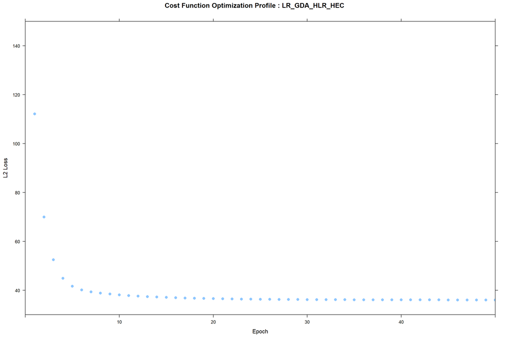

```r
##################################
# Plotting the cost function optimization data
# for the gradient descent algorithm
# with high learning rate and high epoch count
##################################
xyplot(L2Loss ~ Epoch,
       data = LR_GDA_HLR_HEC_Summary,
       main = "Cost Function Optimization Profile : LR_GDA_HLR_HEC",
       ylab = "L2 Loss",
       xlab = "Epoch",
       type=c("p"),
       origin = 0,
       alpha = 0.45,
       pch = 16,
       cex = 1,
       xlim = c(0, 50),
       ylim = c(30, 150))
```

### 1.5.6 Linear Regression - Gradient Descent Algorithm with Low Learning Rate and Low Epoch Count (LR_GDA_LLR_LEC)

**[A]** The gradient descent algorithm was implemented with parameter settings described as follows:  
**[A.1]** Learning Rate = 50 (Low)  
**[A.2]** Epochs = 10 (Low)  
**[B]** The final gradient norm was determined as 0.96221 at the 10th epoch indicating that the minimum threshold of 0.00010 was not achieved prior to the last epoch.  
**[C]** Applying the gradient descent algorithm with a low learning rate and low epoch count, the estimated linear regression coefficients for the given data are as follows:  
**[C.1]** Intercept = -2.39224 (Baseline = -2.71856)  
**[C.2]** MolWeight = +0.89396 (Baseline = +0.20493)  
**[C.3]** NumCarbon = -1.84352 (Baseline = -1.25425)  
**[C.4]** NumChlorine = -1.06912 (Baseline = -0.14419)  
**[C.5]** NumHalogen = -0.38068 (Baseline = -1.01350)  
**[C.6]** NumMultBonds = -0.36341 (Baseline = -0.33048)  
**[D]** The estimated coefficients using the gradient descent algorithm with a low learning rate and low epoch count were not fully optimized and were not comparable with the baseline coefficients using normal equations.

```r
##################################
# Estimating the linear regression coefficients
# using the gradient descent algorithm
# with low learning rate and low epoch count
##################################
LR_GDA_LLR_LEC = GradientDescent_LREstimation(y = y,
                                          X = X,
                                          LearningRate = 50,
                                          Epochs = 10)
```

```
## [1] "Initializing Gradient Descent Algorithm Parameters."
## [1] "Gradient Descent Algorithm Reached Last Epoch Without Convergence."
## [1] "Minimum Threshold for Gradient Norm = 0.0001 Not Achieved."
## [1] "Final Gradient Norm Determined as  0.962210610545313 at Epoch 10"
```

```r
LR_GDA_LLR_LEC_Summary <- LR_GDA_LLR_LEC

##################################
# Consolidating all estimated
# linear regression coefficients
# using the gradient descent algorithm
# with low learning rate and low epoch count
##################################
LR_GDA_LLR_LEC <- as.data.frame(LR_GDA_LLR_LEC_Summary$LRCoefficients)
rownames(LR_GDA_LLR_LEC) <- NULL
colnames(LR_GDA_LLR_LEC) <- c("LRCoefficients")
LR_GDA_LLR_LEC$LRCoefficientNames <- c("Intercept",
                                   "MolWeight",
                                   "NumCarbon",
                                   "NumChlorine",
                                   "NumHalogen",
                                   "NumMultBonds")
LR_GDA_LLR_LEC$EstimationMethod <- rep("LR_GDA_LLR_LEC",nrow(LR_GDA_LLR_LEC))

##################################
# Summarizing the estimated
# linear regression coefficients
# using the gradient descent algorithm
# with low learning rate and low epoch count
##################################
print(LR_GDA_LLR_LEC)
```

```
##   LRCoefficients LRCoefficientNames EstimationMethod
## 1     -2.3922400          Intercept   LR_GDA_LLR_LEC
## 2      0.8939686          MolWeight   LR_GDA_LLR_LEC
## 3     -1.8435282          NumCarbon   LR_GDA_LLR_LEC
## 4     -1.0691289        NumChlorine   LR_GDA_LLR_LEC
## 5     -0.3806898         NumHalogen   LR_GDA_LLR_LEC
## 6     -0.3634163       NumMultBonds   LR_GDA_LLR_LEC
```

```r
##################################
# Gathering the cost function optimization data
# for the gradient descent algorithm
# with low learning rate and low epoch count
##################################
LR_GDA_LLR_LEC_Summary$Epoch <- 1:length(LR_GDA_LLR_LEC_Summary$L2Loss)
LR_GDA_LLR_LEC_Summary$Method <- rep("LR_GDA_LLR_LEC",length(LR_GDA_LLR_LEC_Summary$L2Loss))

L2Loss <- LR_GDA_LLR_LEC_Summary$L2Loss
Epoch  <- LR_GDA_LLR_LEC_Summary$Epoch
Method <- LR_GDA_LLR_LEC_Summary$Method
(LR_GDA_LLR_LEC_ConsolidatedSummary <- cbind(L2Loss, Epoch, Method))
```

```
##       L2Loss             Epoch Method
##  [1,] "128.868015504947" "1"   "LR_GDA_LLR_LEC"
##  [2,] "100.674236221077" "2"   "LR_GDA_LLR_LEC"
##  [3,] "81.8154777197929" "3"   "LR_GDA_LLR_LEC"
##  [4,] "68.7468688791543" "4"   "LR_GDA_LLR_LEC"
##  [5,] "59.590708566118"  "5"   "LR_GDA_LLR_LEC"
##  [6,] "53.1931626792032" "6"   "LR_GDA_LLR_LEC"
##  [7,] "48.758193032101"  "7"   "LR_GDA_LLR_LEC"
##  [8,] "45.7046714572526" "8"   "LR_GDA_LLR_LEC"
##  [9,] "43.605750421321"  "9"   "LR_GDA_LLR_LEC"
## [10,] "42.1544665405458" "10"  "LR_GDA_LLR_LEC"
```

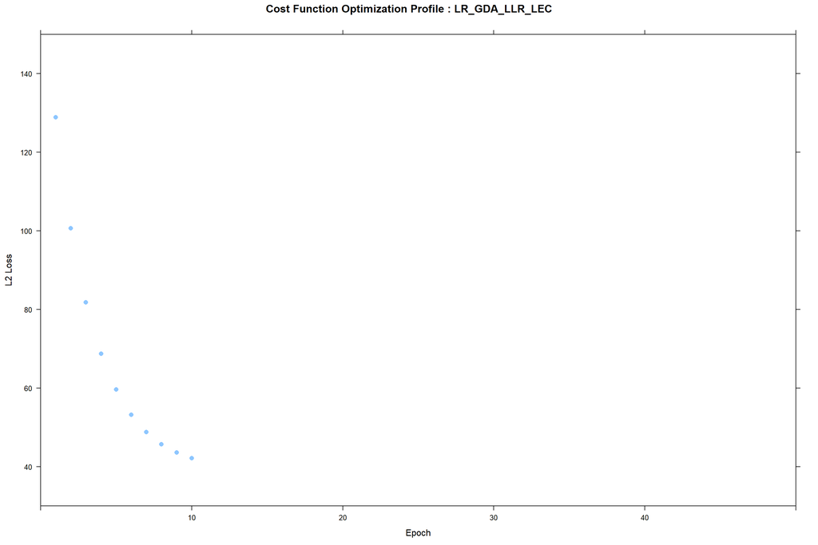

```r
##################################
# Plotting the cost function optimization data
# for the gradient descent algorithm
# with low learning rate and low epoch count
##################################
xyplot(L2Loss ~ Epoch,
       data = LR_GDA_LLR_LEC_Summary,
       main = "Cost Function Optimization Profile : LR_GDA_LLR_LEC",
       ylab = "L2 Loss",
       xlab = "Epoch",
       type=c("p"),
       origin = 0,
       alpha = 0.45,
       pch = 16,
       cex = 1,
       xlim = c(0, 50),
       ylim = c(30, 150))
```

### 1.5.7 Linear Regression - Gradient Descent Algorithm with Low Learning Rate and High Epoch Count (LR_GDA_LLR_HEC)

**[A]** The gradient descent algorithm was implemented with parameter settings described as follows:  
**[A.1]** Learning Rate = 50 (Low)  
**[A.2]** Epochs = 50 (High)  
**[B]** The final gradient norm was determined as 0.11481 at the 50th epoch indicating that the minimum threshold of 0.00010 was not achieved prior to the last epoch.  
**[C]** Applying the gradient descent algorithm with a low learning rate and high epoch count, the estimated linear regression coefficients for the given data are as follows:  
**[C.1]** Intercept = -2.71854 (Baseline = -2.71856)  
**[C.2]** MolWeight = +0.28134 (Baseline = +0.20493)  
**[C.3]** NumCarbon = -1.33710 (Baseline = -1.25425)  
**[C.4]** NumChlorine = -0.51277 (Baseline = -0.14419)  
**[C.5]** NumHalogen = -0.68397 (Baseline = -1.01350)  
**[C.6]** NumMultBonds = -0.31132 (Baseline = -0.33048)  
**[D]** The estimated coefficients using the gradient descent algorithm with a low learning rate and high epoch count, while not fully optimized, were sufficiently comparable with the baseline coefficients using normal equations.

```r
##################################
# Estimating the linear regression coefficients
# using the gradient descent algorithm
# with low learning rate and high epoch count
##################################
LR_GDA_LLR_HEC = GradientDescent_LREstimation(y = y,
                                          X = X,
                                          LearningRate = 50,
                                          Epochs = 50)
```

```
## [1] "Initializing Gradient Descent Algorithm Parameters."
## [1] "Gradient Descent Algorithm Reached Last Epoch Without Convergence."
## [1] "Minimum Threshold for Gradient Norm = 0.0001 Not Achieved."
## [1] "Final Gradient Norm Determined as  0.114815262946592 at Epoch 50"
```

```r
LR_GDA_LLR_HEC_Summary <- LR_GDA_LLR_HEC

##################################
# Consolidating all estimated
# linear regression coefficients
# using the gradient descent algorithm
# with low learning rate and high epoch count
##################################
LR_GDA_LLR_HEC <- as.data.frame(LR_GDA_LLR_HEC_Summary$LRCoefficients)
rownames(LR_GDA_LLR_HEC) <- NULL
colnames(LR_GDA_LLR_HEC) <- c("LRCoefficients")
LR_GDA_LLR_HEC$LRCoefficientNames <- c("Intercept",
                                   "MolWeight",
                                   "NumCarbon",
                                   "NumChlorine",
                                   "NumHalogen",
                                   "NumMultBonds")
LR_GDA_LLR_HEC$EstimationMethod <- rep("LR_GDA_LLR_HEC",nrow(LR_GDA_LLR_HEC))

##################################
# Summarizing the estimated
# linear regression coefficients
# using the gradient descent algorithm
# with low learning rate and high epoch count
##################################
print(LR_GDA_LLR_HEC)
```

```
##   LRCoefficients LRCoefficientNames EstimationMethod
## 1     -2.7185441          Intercept   LR_GDA_LLR_HEC
## 2      0.2813439          MolWeight   LR_GDA_LLR_HEC
## 3     -1.3371016          NumCarbon   LR_GDA_LLR_HEC
## 4     -0.5127712        NumChlorine   LR_GDA_LLR_HEC
## 5     -0.6839773         NumHalogen   LR_GDA_LLR_HEC
## 6     -0.3113283       NumMultBonds   LR_GDA_LLR_HEC
```

```r
##################################
# Gathering the cost function optimization data
# for the gradient descent algorithm
# with low learning rate and high epoch count
##################################
LR_GDA_LLR_HEC_Summary$Epoch <- 1:length(LR_GDA_LLR_HEC_Summary$L2Loss)
LR_GDA_LLR_HEC_Summary$Method <- rep("LR_GDA_LLR_HEC",length(LR_GDA_LLR_HEC_Summary$L2Loss))

L2Loss <- LR_GDA_LLR_HEC_Summary$L2Loss
Epoch  <- LR_GDA_LLR_HEC_Summary$Epoch
Method <- LR_GDA_LLR_HEC_Summary$Method
(LR_GDA_LLR_HEC_ConsolidatedSummary <- cbind(L2Loss, Epoch, Method))
```

```
##       L2Loss             Epoch Method
##  [1,] "128.868015504947" "1"   "LR_GDA_LLR_HEC"
##  [2,] "100.674236221077" "2"   "LR_GDA_LLR_HEC"
##  [3,] "81.8154777197929" "3"   "LR_GDA_LLR_HEC"
##  [4,] "68.7468688791543" "4"   "LR_GDA_LLR_HEC"
##  [5,] "59.590708566118"  "5"   "LR_GDA_LLR_HEC"
##  [6,] "53.1931626792032" "6"   "LR_GDA_LLR_HEC"
##  [7,] "48.758193032101"  "7"   "LR_GDA_LLR_HEC"
##  [8,] "45.7046714572526" "8"   "LR_GDA_LLR_HEC"
##  [9,] "43.605750421321"  "9"   "LR_GDA_LLR_HEC"
## [10,] "42.1544665405458" "10"  "LR_GDA_LLR_HEC"
## [11,] "41.1364565433462" "11"  "LR_GDA_LLR_HEC"
## [12,] "40.406033177599"  "12"  "LR_GDA_LLR_HEC"
## [13,] "39.8662448387947" "13"  "LR_GDA_LLR_HEC"
## [14,] "39.4534953274598" "14"  "LR_GDA_LLR_HEC"
```

[output cut: 36 more lines]

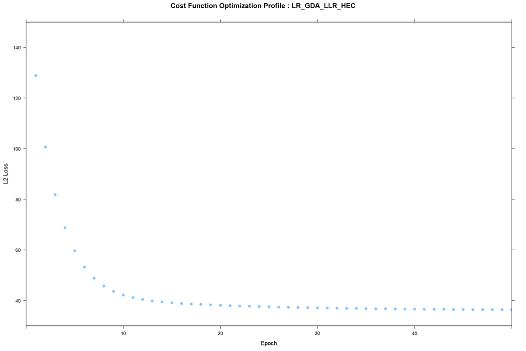

```r
##################################
# Plotting the cost function optimization data
# for the gradient descent algorithm
# with low learning rate and high epoch count
##################################
xyplot(L2Loss ~ Epoch,
       data = LR_GDA_LLR_HEC_Summary,
       main = "Cost Function Optimization Profile : LR_GDA_LLR_HEC",
       ylab = "L2 Loss",
       xlab = "Epoch",
       type=c("p"),
       origin = 0,
       alpha = 0.45,
       pch = 16,
       cex = 1,
       xlim = c(0, 50),
       ylim = c(30, 150))
```

## 1.6 Linear Regression Model Coefficient Estimation Evaluation Summary

**[A]** The gradient descent algorithms with sufficiently comparable coefficients with the baseline despite not achieving fully optimized coefficients are as follows:  
**[A.1]** LR_GDA_HLR_HEC : Linear Regression - Gradient Descent Algorithm with High Learning Rate and High Epoch Count  
**[A.2]** LR_GDA_LLR_HEC : Linear Regression - Gradient Descent Algorithm with Low Learning Rate and High Epoch Count  
**[A.3]** LR_GDA_VHLR_HLEC : Linear Regression - Gradient Descent Algorithm with Very High Learning Rate and Low Epoch Count  
**[A]** The choice of gradient norm minimum threshold for convergence, learning rate and the epoch count in the implementation of the gradient descent algorithm are critical to achieving fully optimized coefficients while maintaining a sensibly minimal cost function.

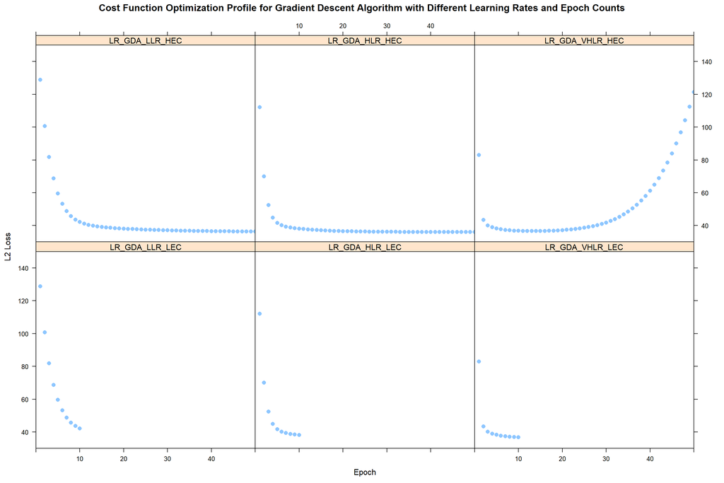

```r
##################################
# Consolidating the cost function optimization data
# for all gradient descent algorithms
# with different learning rates and epoch counts
##################################
LR_GDA_ConsolidatedSummary <- rbind(LR_GDA_VHLR_LEC_ConsolidatedSummary,
                                    LR_GDA_VHLR_HEC_ConsolidatedSummary,
                                    LR_GDA_HLR_LEC_ConsolidatedSummary,
                                    LR_GDA_HLR_HEC_ConsolidatedSummary,
                                    LR_GDA_LLR_LEC_ConsolidatedSummary,
                                    LR_GDA_LLR_HEC_ConsolidatedSummary)

LR_GDA_ConsolidatedSummary <- as.data.frame(LR_GDA_ConsolidatedSummary)

LR_GDA_ConsolidatedSummary$L2Loss <- as.numeric(as.character(LR_GDA_ConsolidatedSummary$L2Loss))
LR_GDA_ConsolidatedSummary$Epoch  <- as.numeric(as.character(LR_GDA_ConsolidatedSummary$Epoch))
LR_GDA_ConsolidatedSummary$Method <- factor(LR_GDA_ConsolidatedSummary$Method,
                                            levels = c("LR_GDA_LLR_LEC",
                                                       "LR_GDA_HLR_LEC",
                                                       "LR_GDA_VHLR_LEC",
                                                       "LR_GDA_LLR_HEC",
                                                       "LR_GDA_HLR_HEC",
                                                       "LR_GDA_VHLR_HEC"))

##################################
# Plotting the cost function optimization data
# for all gradient descent algorithms
# with different learning rates and epoch counts
##################################
xyplot(L2Loss ~ Epoch | Method,
       data = LR_GDA_ConsolidatedSummary,
       main = "Cost Function Optimization Profile for Gradient Descent Algorithm with Different Learning Rates and Epoch Counts",
       ylab = "L2 Loss",
       xlab = "Epoch",
       type=c("p"),
       origin = 0,
       alpha = 0.45,
       pch = 16,
       cex = 1,
       xlim = c(0, 50),
       ylim = c(30, 150))
```

```r
##################################
# Gathering the estimated coefficients
# for normal equations and all gradient descent algorithms
# with different learning rates and epoch counts
##################################
LR_NE_VS_LR_GDA_VHLR_LEC <- as.data.frame(LR_NE)
LR_NE_VS_LR_GDA_VHLR_HEC <- as.data.frame(LR_NE)
LR_NE_VS_LR_GDA_HLR_LEC <- as.data.frame(LR_NE)
LR_NE_VS_LR_GDA_HLR_HEC <- as.data.frame(LR_NE)
LR_NE_VS_LR_GDA_LLR_LEC <- as.data.frame(LR_NE)
LR_NE_VS_LR_GDA_LLR_HEC <- as.data.frame(LR_NE)

LR_NE_VS_LR_GDA_VHLR_LEC$Group <- rep("LR_NE Versus LR_GDA_VHLR_LEC",nrow(LR_NE_VS_LR_GDA_VHLR_LEC))
LR_NE_VS_LR_GDA_VHLR_HEC$Group <- rep("LR_NE Versus LR_GDA_VHLR_HEC",nrow(LR_NE_VS_LR_GDA_VHLR_LEC))
LR_NE_VS_LR_GDA_HLR_LEC$Group <- rep("LR_NE Versus LR_GDA_HLR_LEC",nrow(LR_NE_VS_LR_GDA_HLR_LEC))
LR_NE_VS_LR_GDA_HLR_HEC$Group <- rep("LR_NE Versus LR_GDA_HLR_HEC",nrow(LR_NE_VS_LR_GDA_HLR_LEC))
LR_NE_VS_LR_GDA_LLR_LEC$Group <- rep("LR_NE Versus LR_GDA_LLR_LEC",nrow(LR_NE_VS_LR_GDA_HLR_LEC))
LR_NE_VS_LR_GDA_LLR_HEC$Group <- rep("LR_NE Versus LR_GDA_LLR_HEC",nrow(LR_NE_VS_LR_GDA_HLR_LEC))
LR_GDA_VHLR_LEC$Group <- rep("LR_NE Versus LR_GDA_VHLR_LEC",nrow(LR_GDA_VHLR_LEC))
LR_GDA_VHLR_HEC$Group <- rep("LR_NE Versus LR_GDA_VHLR_HEC",nrow(LR_GDA_VHLR_HEC))
LR_GDA_HLR_LEC$Group <- rep("LR_NE Versus LR_GDA_HLR_LEC",nrow(LR_GDA_HLR_LEC))
LR_GDA_HLR_HEC$Group <- rep("LR_NE Versus LR_GDA_HLR_HEC",nrow(LR_GDA_HLR_HEC))
LR_GDA_LLR_LEC$Group <- rep("LR_NE Versus LR_GDA_LLR_LEC",nrow(LR_GDA_LLR_LEC))
LR_GDA_LLR_HEC$Group <- rep("LR_NE Versus LR_GDA_LLR_HEC",nrow(LR_GDA_LLR_HEC))

##################################
# Consolidating the estimated coefficients
# for normal equations and all gradient descent algorithms
# with different learning rates and epoch counts
##################################
LR_NE_GDA_ConsolidatedSummary <- rbind(LR_NE_VS_LR_GDA_VHLR_LEC,
                                       LR_NE_VS_LR_GDA_VHLR_HEC,
                                       LR_NE_VS_LR_GDA_HLR_LEC,
                                       LR_NE_VS_LR_GDA_HLR_HEC,
                                       LR_NE_VS_LR_GDA_LLR_LEC,
                                       LR_NE_VS_LR_GDA_LLR_HEC,
                                       LR_GDA_VHLR_LEC,
                                       LR_GDA_VHLR_HEC,
                                       LR_GDA_HLR_LEC,
                                       LR_GDA_HLR_HEC,
                                       LR_GDA_LLR_LEC,
                                       LR_GDA_LLR_HEC)

LR_NE_GDA_ConsolidatedSummary <- as.data.frame(LR_NE_GDA_ConsolidatedSummary)

LR_NE_GDA_ConsolidatedSummary$LRCoefficients <- as.numeric(as.character(LR_NE_GDA_ConsolidatedSummary$LRCoefficients))
LR_NE_GDA_ConsolidatedSummary$Group <- factor(LR_NE_GDA_ConsolidatedSummary$Group,
                                              levels = c("LR_NE Versus LR_GDA_LLR_LEC",
                                                         "LR_NE Versus LR_GDA_HLR_LEC",
                                                         "LR_NE Versus LR_GDA_VHLR_LEC",
                                                         "LR_NE Versus LR_GDA_LLR_HEC",
                                                         "LR_NE Versus LR_GDA_HLR_HEC",
                                                         "LR_NE Versus LR_GDA_VHLR_HEC"))

LR_NE_GDA_ConsolidatedSummary$LRCoefficientNames <- factor(LR_NE_GDA_ConsolidatedSummary$LRCoefficientNames,
                                                           levels = c("NumMultBonds",
                                                                      "NumHalogen",
                                                                      "NumChlorine",
                                                                      "NumCarbon",
                                                                      "MolWeight",
                                                                      "Intercept"))

LR_NE_GDA_ConsolidatedSummary$EstimationMethod <- factor(LR_NE_GDA_ConsolidatedSummary$EstimationMethod,
                                                         levels = c("LR_NE",
                                                                    "LR_GDA_LLR_LEC",
                                                                    "LR_GDA_LLR_HEC",
                                                                    "LR_GDA_HLR_LEC",
                                                                    "LR_GDA_HLR_HEC",
                                                                    "LR_GDA_VHLR_LEC",
                                                                    "LR_GDA_VHLR_HEC"))

print(LR_NE_GDA_ConsolidatedSummary)
```

```
##    LRCoefficients LRCoefficientNames EstimationMethod
## 1      -2.7185699          Intercept            LR_NE
## 2       0.2049318          MolWeight            LR_NE
## 3      -1.2542520          NumCarbon            LR_NE
## 4      -0.1441934        NumChlorine            LR_NE
## 5      -1.0135099         NumHalogen            LR_NE
## 6      -0.3304828       NumMultBonds            LR_NE
## 7      -2.7185699          Intercept            LR_NE
## 8       0.2049318          MolWeight            LR_NE
## 9      -1.2542520          NumCarbon            LR_NE
## 10     -0.1441934        NumChlorine            LR_NE
## 11     -1.0135099         NumHalogen            LR_NE
## 12     -0.3304828       NumMultBonds            LR_NE
## 13     -2.7185699          Intercept            LR_NE
## 14      0.2049318          MolWeight            LR_NE
```

[output cut: 131 more lines]

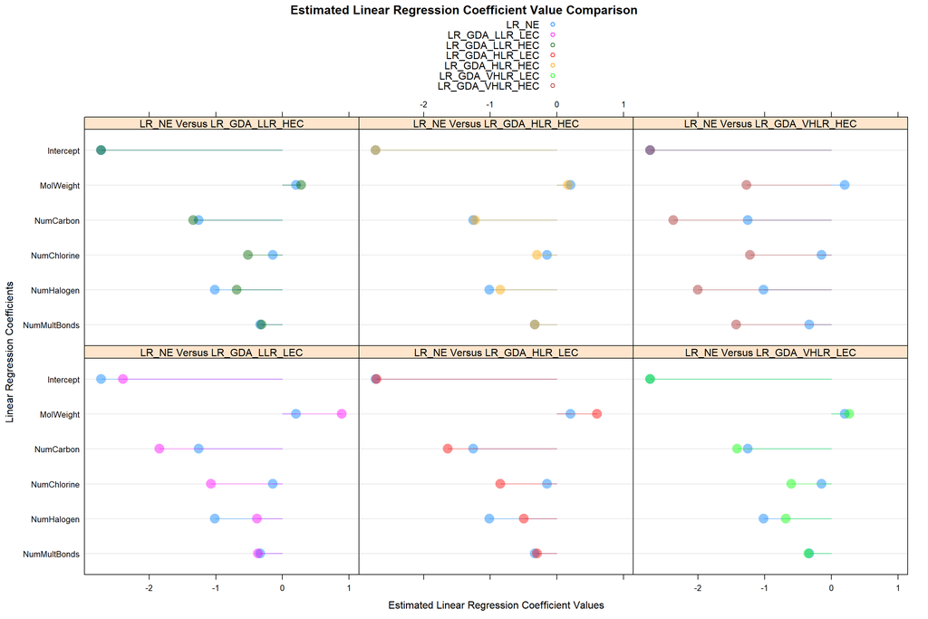

```r
dotplot(LRCoefficientNames ~ LRCoefficients | Group,
        data = LR_NE_GDA_ConsolidatedSummary,
        groups = EstimationMethod,
        main = "Estimated Linear Regression Coefficient Value Comparison",
        ylab = "Linear Regression Coefficients",
        xlab = "Estimated Linear Regression Coefficient Values",
        auto.key = list(adj = 1),
        type = c("p", "h"),
        # origin = 0,
        alpha = 0.45,
        pch = 16,
        cex = 2)
```

## 1.7 References

**[Book]** [Applied Predictive Modeling](http://appliedpredictivemodeling.com/) by Max Kuhn and Kjell Johnson  
**[Book]** [An Introduction to Statistical Learning](https://www.statlearning.com/) by Gareth James, Daniela Witten, Trevor Hastie and Rob Tibshirani  
**[Book]** [Multivariate Data Visualization with R](http://lmdvr.r-forge.r-project.org/figures/figures.html) by Deepayan Sarkar  
**[Book]** [Machine Learning](https://bookdown.org/ssjackson300/Machine-Learning-Lecture-Notes/) by Samuel Jackson  
**[Book]** [Data Modeling Methods](https://bookdown.org/larget_jacob/data-modeling-methods/) by Jacob Larget  
**[Book]** [Introduction to R](https://biocorecrg.github.io/CRG_RIntroduction/) by Sara Bonnin  
**[R Package]** [AppliedPredictiveModeling](https://cran.r-project.org/web//packages/AppliedPredictiveModeling/AppliedPredictiveModeling.pdf) by Max Kuhn  
**[R Package]** [caret](https://topepo.github.io/caret/index.html) by Max Kuhn  
**[R Package]** [rpart](https://mran.microsoft.com/web/packages/rpart/rpart.pdf) by Terry Therneau and Beth Atkinson  
**[R Package]** [lattice](https://cran.r-project.org/web/packages/lattice/lattice.pdf) by Deepayan Sarkar  
**[R Package]** [dplyr](https://cran.r-project.org/web/packages/dplyr/index.html/) by Hadley Wickham  
**[R Package]** [moments](https://cran.r-project.org/web/packages/moments/index.html) by Lukasz Komsta and Frederick  
**[R Package]** [skimr](https://cran.r-project.org/web/packages/skimr/skimr.pdf) by Elin Waring  
**[R Package]** [RANN](https://cran.r-project.org/web/packages/RANN/RANN.pdf) by Sunil Arya, David Mount, Samuel Kemp and Gregory Jefferis  
**[R Package]** [corrplot](https://cran.r-project.org/web/packages/corrplot/corrplot.pdf) by Taiyun Wei  
**[R Package]** [tidyverse](https://cran.r-project.org/web/packages/tidyverse/tidyverse.pdf) by Hadley Wickham  
**[R Package]** [lares](https://cran.rstudio.com/web/packages/lares/lares.pdf) by Bernardo Lares  
**[R Package]** [DMwR](https://mran.microsoft.com/snapshot/2016-05-02/web/packages/DMwR/DMwR.pdf) by Luis Torgo  
**[R Package]** [gridExtra](https://cran.r-project.org/web/packages/gridExtra/gridExtra.pdf) by Baptiste Auguie and Anton Antonov  
**[R Package]** [rattle](https://cran.r-project.org/web/packages/rattle/rattle.pdf) by Graham Williams  
**[R Package]** [rpart.plot](https://cran.r-project.org/web/packages/rpart.plot/rpart.plot.pdf) by Stephen Milborrow  
**[R Package]** [RColorBrewer](https://cran.r-project.org/web//packages/RColorBrewer/RColorBrewer.pdf) by Erich Neuwirth  
**[R Package]** [stats](https://search.r-project.org/R/refmans/stats/html/00Index.html) by R Core Team  
**[Article]** [The caret Package](https://topepo.github.io/caret/index.html) by Max Kuhn  
**[Article]** [A Short Introduction to the caret Package](https://cran.r-project.org/web/packages/caret/vignettes/caret.html) by Max Kuhn  
**[Article]** Caret Package – A Practical Guide to Machine Learning in R by Selva Prabhakaran  
**[Article]** [Tuning Machine Learning Models Using the Caret R Package](https://machinelearningmastery.com/tuning-machine-learning-models-using-the-caret-r-package/) by Jason Brownlee  
**[Article]** [Lattice Graphs](http://www.sthda.com/english/wiki/lattice-graphs) by STHDA Team  
**[Article]** [A Tour of Machine Learning Algorithms](https://machinelearningmastery.com/a-tour-of-machine-learning-algorithms/) by Jason Brownlee  
**[Article]** [Gradient Descent and Stochastic Gradient Descent in R](https://www.ocf.berkeley.edu/~janastas/stochastic-gradient-descent-in-r.html) by Jason Anastasopoulos  
**[Article]** [Linear Regression Tutorial Using Gradient Descent for Machine Learning](https://machinelearningmastery.com/linear-regression-tutorial-using-gradient-descent-for-machine-learning/) by Jason Brownlee  
**[Article]** [An Overview of Gradient Descent Optimization Algorithms](https://ruder.io/optimizing-gradient-descent/) by Sebastian Ruder  
**[Article]** [What is Gradient Descent?](https://www.ibm.com/topics/gradient-descent) by IBM Team  
**[Article]** [Gradient Descent in Machine Learning: A Basic Introduction](https://builtin.com/data-science/gradient-descent) by Niklas Donges  
**[Article]** [Gradient Descent for Linear Regression Explained, Step by Step](https://machinelearningcompass.com/machine_learning_math/gradient_descent_for_linear_regression/) by Boris Giba  
**[Article]** [Gradient Descent Explained Simply with Examples](https://vitalflux.com/gradient-descent-explained-simply-with-examples/) by Ajitesh Kumar  
**[Article]** [Implementing the Gradient Descent Algorithm in R](https://www.r-bloggers.com/2017/02/implementing-the-gradient-descent-algorithm-in-r/) by Richter Walsh  
**[Article]** [Regression via Gradient Descent in R](https://www.r-bloggers.com/2011/11/regression-via-gradient-descent-in-r/) by Matt Bogard  
**[Article]** [Difference Between Batch Gradient Descent and Stochastic Gradient Descent](https://www.geeksforgeeks.org/difference-between-batch-gradient-descent-and-stochastic-gradient-descent/) by Geeks For Geeks Team  
**[Article]** [Stochastic Gradient Descent Vs Gradient Descent: A Head-To-Head Comparison](https://sdsclub.com/stochastic-gradient-descent-vs-gradient-descent-a-head-to-head-comparison/) by SDS Club Team  
**[Article]** [Differences Between Gradient, Stochastic and Mini Batch Gradient Descent](https://www.baeldung.com/cs/gradient-stochastic-and-mini-batch) by Baeldung  
**[Article]** [Difference Between Backpropagation and Stochastic Gradient Descent](https://machinelearningmastery.com/difference-between-backpropagation-and-stochastic-gradient-descent/) by Jason Brownlee  
**[Article]** [ML | Normal Equation in Linear Regression](https://www.geeksforgeeks.org/ml-normal-equation-in-linear-regression/) by Geeks For Geeks Team  
**[Article]** [Derivation of the Normal Equation for Linear Regression](https://eli.thegreenplace.net/2014/derivation-of-the-normal-equation-for-linear-regression/) by Eli Bendersky  
**[Article]** [Normal Equation](http://mlwiki.org/index.php/Normal_Equation) by ML Wiki Team  
**[Course]** [Applied Data Mining and Statistical Learning](https://online.stat.psu.edu/stat508/) by Penn State Eberly College of Science  
**[Course]** [Regression Methods](https://online.stat.psu.edu/stat501/) by Penn State Eberly College of Science  
**[Course]** [Applied Regression Analysis](https://online.stat.psu.edu/stat462/) by Penn State Eberly College of Science  
**[Course]** [Applied Data Mining and Statistical Learning](https://online.stat.psu.edu/stat508/) by Penn State Eberly College of Science